# Jared Smith | False Alerts in Cook County’s Electronic Monitoring System

## June 2025

# Research Question:

My project aims to study potential associations between electronic monitoring false alerts and Chicago's built environment.

Electronic monitoring is a form of remote surveillance law enforcement uses as an alternative to incarceration: a person on house arrest may be tracked via a GPS ankle monitor, for example. However, GPS has limitations that can affect the accuracy of its monitoring: GPS signals are compromised by interference in densely built-up urban areas. This can lead to 'false alerts', when a GPS error makes it seem like a person is breaking the terms of their home arrest, even though no violation occurred. There are reports that false alerts have caused rule-following supervisees to be harassed by law enforcement.

I will measure the rate of false alerts by zip code. Is there a relationship between the rate of false alerts and zip codes with high building heights? Is the relationship between the rate of false alerts and zip codes with a high building density?

Through my code, I will run a correlation analysis between the rate of false alerts and average building height and building density. I will also map these variables to analayze a potential spatial realtionship.

# Data Overview:

I am using two main datasets for this project. My Electronic Monitoring False Alert data comes from the Cook County Sheriff's Office, and my Chicago building structure data comes from the FEMA USA Struture Data Set. I will also be using a shapefile of Chicago's Zip codes in order to map the data.

# Workflow Overview

- My primary goal is to merge the Chicago Structures, False Alert by Zip Code, and Zip Code Shapefiles into a single dataset organized by zip code. The False Alert by Zip Code and Zip Code Shapefiles are already organized by zip code, so the majority of my work is focused on organizing the Chicago Structures dataset.
- 10,672 structures did not have an assigned zip code; they contained “null” values in the zip code column. However, since the structural data does contain the latitude and longitude of these structures, I was able to join these structures to the zip code shapefile table spatially.
- After the null zip codes were updated, I was able to organize the structural data by zip code.
- I was able to find the area of the Zip Codes by using the Zip Codes shapefile, which allowed me to find the average building density per square meter for each zip code. I was then able to combine the structural data and false alert data to the zip code shapefile by using the zip code as a common key.
- I then was able to run a correlation analysis and map the geospatial data.

# Code: Import Data

## Import Packages

```python
import matplotlib.pyplot as plt
import numpy as np
import pandas as pd
import geopandas as gpd
import seaborn as sns
import scipy.stats
from scipy.stats import spearmanr
```

## Reading Data Files

```python
#Get False Alert by Data Object
faz = gpd.read_file('data/falseAlerts_byZip_OG.xlsx')
```

```python
#Get Chicago Building Structure Data Object
cbs = gpd.read_file('data/Chicago_structures_raw.xlsx')
```

```python
#Zip code Shapefiles
path = 'https://data.cityofchicago.org/resource/unjd-c2ca.geojson'
zcodes = gpd.read_file(path)
```

# Code: Data Wrangling

## Clean Up False Alert by Zip Code (FAZ) Data

```python
faz.columns
```

```
Index(['OBJECTID', 'ZIP_CODE', 'PO_NAME', 'STATE', 'POPULATION', 'POP_SQMI',
       'SQMI', 'ZIP_int', 'Zip', 'Total_Alerts', 'False_Alerts',
       'Shape_Length', 'Shape_Area'],
      dtype='object')
```

```python
#drop uneccesary columns
faz = faz.drop(columns = ['PO_NAME', 'STATE', 'POPULATION', 'POP_SQMI', 'SQMI', 'ZIP_int', 'Zip'])
```

```python
# drop row with NuLL Zip Codes
faz = faz.drop([56])
```

```python
faz
```

|  | OBJECTID | ZIP_CODE | Total_Alerts | False_Alerts | Shape_Length | Shape_Area |
| --- | --- | --- | --- | --- | --- | --- |
| 0 | 1 | 60601 | 934.0 | 921.0 | 0.066747 | 0.000094 |
| 1 | 2 | 60602 | 4.0 | 4.0 | 0.034100 | 0.000033 |
| 2 | 3 | 60604 | 33.0 | 30.0 | 0.024159 | 0.000024 |
| 3 | 4 | 60605 | 1922.0 | 1904.0 | 0.146242 | 0.000417 |
| 4 | 5 | 60607 | 1719.0 | 1681.0 | 0.128016 | 0.000644 |
| 5 | 6 | 60608 | 24919.0 | 24515.0 | 0.172796 | 0.001782 |
| 6 | 7 | 60609 | 1940.0 | 1857.0 | 0.190443 | 0.002131 |
| 7 | 8 | 60610 | 2364.0 | 2322.0 | 0.082149 | 0.000300 |
| 8 | 9 | 60611 | 725.0 | 718.0 | 0.152955 | 0.000249 |
| 9 | 10 | 60612 | 4313.0 | 4199.0 | 0.137876 | 0.001071 |
| 10 | 11 | 60613 | 634.0 | 621.0 | 0.137508 | 0.000530 |
| 11 | 12 | 60614 | 571.0 | 565.0 | 0.164186 | 0.000943 |
| 12 | 13 | 60615 | 6247.0 | 6118.0 | 0.129218 | 0.000665 |
| 13 | 14 | 60616 | 1413.0 | 1362.0 | 0.151035 | 0.001061 |
| 14 | 15 | 60617 | 3661.0 | 3501.0 | 0.440490 | 0.004946 |
| 15 | 16 | 60618 | 1182.0 | 1157.0 | 0.157953 | 0.001423 |
| 16 | 17 | 60619 | 7733.0 | 7316.0 | 0.168261 | 0.001710 |
| 17 | 18 | 60620 | 4481.0 | 4219.0 | 0.207882 | 0.001938 |
| 18 | 19 | 60621 | 4279.0 | 4048.0 | 0.134638 | 0.001058 |
| 19 | 20 | 60622 | 708.0 | 684.0 | 0.153680 | 0.000729 |
| 20 | 21 | 60623 | 5949.0 | 5756.0 | 0.174836 | 0.001530 |
| 21 | 22 | 60624 | 5085.0 | 4929.0 | 0.128588 | 0.000998 |
| 22 | 23 | 60625 | 768.0 | 728.0 | 0.146529 | 0.001030 |
| 23 | 24 | 60626 | 1036.0 | 986.0 | 0.104386 | 0.000498 |
| 24 | 25 | 60628 | 4876.0 | 4653.0 | 0.250079 | 0.003053 |
| 25 | 26 | 60629 | 3442.0 | 3303.0 | 0.205093 | 0.002118 |
| 26 | 27 | 60630 | 258.0 | 254.0 | 0.187152 | 0.001332 |
| 27 | 28 | 60631 | 405.0 | 400.0 | 0.230987 | 0.001083 |
| 28 | 29 | 60632 | 2170.0 | 2101.0 | 0.216008 | 0.002158 |
| 29 | 30 | 60633 | 581.0 | 563.0 | 0.365700 | 0.002433 |
| 30 | 31 | 60634 | 1160.0 | 1133.0 | 0.242853 | 0.001846 |
| 31 | 32 | 60636 | 2697.0 | 2558.0 | 0.131216 | 0.001061 |
| 32 | 33 | 60637 | 6100.0 | 5897.0 | 0.178468 | 0.001270 |
| 33 | 34 | 60638 | 457.0 | 441.0 | 0.261343 | 0.003222 |
| 34 | 35 | 60639 | 3997.0 | 3852.0 | 0.162119 | 0.001288 |
| 35 | 36 | 60640 | 1847.0 | 1792.0 | 0.198222 | 0.000824 |
| 36 | 37 | 60641 | 1744.0 | 1712.0 | 0.138909 | 0.001151 |
| 37 | 38 | 60642 | 143.0 | 132.0 | 0.118637 | 0.000481 |
| 38 | 39 | 60643 | 2071.0 | 2002.0 | 0.253251 | 0.002088 |
| 39 | 40 | 60644 | 4193.0 | 4037.0 | 0.127628 | 0.001002 |
| 40 | 41 | 60645 | 1664.0 | 1627.0 | 0.110572 | 0.000632 |
| 41 | 42 | 60646 | 77.0 | 77.0 | 0.244576 | 0.001080 |
| 42 | 43 | 60647 | 1945.0 | 1893.0 | 0.143522 | 0.001072 |
| 43 | 44 | 60649 | 5588.0 | 5380.0 | 0.150670 | 0.000816 |
| 44 | 45 | 60651 | 3801.0 | 3680.0 | 0.166228 | 0.000994 |
| 45 | 46 | 60652 | 561.0 | 527.0 | 0.168199 | 0.001274 |
| 46 | 47 | 60653 | 2597.0 | 2533.0 | 0.118160 | 0.000682 |
| 47 | 48 | 60654 | 115.0 | 113.0 | 0.066452 | 0.000176 |
| 48 | 49 | 60655 | 6.0 | 6.0 | 0.241071 | 0.001078 |
| 49 | 50 | 60657 | 277.0 | 272.0 | 0.140948 | 0.000627 |
| 50 | 51 | 60659 | 1048.0 | 1023.0 | 0.149166 | 0.000776 |
| 51 | 52 | 60660 | 1341.0 | 1283.0 | 0.087551 | 0.000353 |
| 52 | 53 | 60661 | 223.0 | 215.0 | 0.039994 | 0.000093 |
| 53 | 54 | 60603 | NaN | NaN | 0.061096 | 0.000065 |
| 54 | 55 | 60606 | NaN | NaN | 0.035843 | 0.000068 |
| 55 | 56 | 60666 | NaN | NaN | 0.253173 | 0.002109 |

## Clean Up Chicago Building Structure (CBS) Data

```python
cbs
```

|  | OBJECTID | BUILD_ID | OCC_CLS | PRIM_OCC | SEC_OCC | PROP_ADDR | PROP_CITY | PROP_ST | PROP_ZIP | OUTBLDG | ... | POP_CI95_UPPER | CENSUSCODE | PROD_DATE | SOURCE | IMAGE_NAME | IMAGE_DATE | VAL_METHOD | REMARKS | Shape_Length | Shape_Area |
| --- | --- | --- | --- | --- | --- | --- | --- | --- | --- | --- | --- | --- | --- | --- | --- | --- | --- | --- | --- | --- | --- |
| 0 | 1 | 34135648 | Residential | Multi - Family Dwelling | None | 1180 SOUTH PLYMOUTH COURT | CHICAGO | Illinois | 60605 | None | ... | None | 17031839000 | 2011-11-15 | NGA | Li213-Chicago | 2011-11-15 | Unverified | None | 81.427794 | 257.523726 |
| 1 | 2 | 34135649 | Residential | Multi - Family Dwelling | None | 1182 SOUTH PLYMOUTH COURT | CHICAGO | Illinois | 60605 | None | ... | None | 17031839000 | 2011-11-15 | NGA | Li213-Chicago | 2011-11-15 | Unverified | None | 85.888419 | 282.540615 |
| 2 | 3 | 34135650 | Commercial | Retail Trade | None | 430 WEST ROOSEVELT ROAD | CHICAGO | Illinois | 60607 | None | ... | None | 17031841900 | 2011-11-15 | NGA | Li213-Chicago | 2011-11-15 | Unverified | None | 158.786046 | 1278.278748 |
| 3 | 4 | 34135651 | Residential | Multi - Family Dwelling | None | 1182 SOUTH PLYMOUTH COURT | CHICAGO | Illinois | 60605 | None | ... | None | 17031839000 | 2011-11-15 | NGA | Li213-Chicago | 2011-11-15 | Unverified | None | 71.706534 | 226.613134 |
| 4 | 5 | 34135652 | Residential | Multi - Family Dwelling | None | 1180 SOUTH PLYMOUTH COURT | CHICAGO | Illinois | 60605 | None | ... | None | 17031839000 | 2011-11-15 | NGA | Li213-Chicago | 2011-11-15 | Unverified | None | 79.869051 | 260.051673 |
| ... | ... | ... | ... | ... | ... | ... | ... | ... | ... | ... | ... | ... | ... | ... | ... | ... | ... | ... | ... | ... | ... |
| 557536 | 557537 | 30408910 | Residential | Multi - Family Dwelling | None | 3231 NORTH KEATING AVENUE | CHICAGO | Illinois | 60641 | None | ... | None | 17031151002 | 2020-01-27 | ORNL | 1040010012089F00 | 2015-09-21 | Automated | None | 39.954249 | 99.771029 |
| 557537 | 557538 | 30409151 | Residential | Multi - Family Dwelling | None | None | None | Illinois | None | None | ... | None | 17031151002 | 2020-01-27 | ORNL | 1040010012089F00 | 2015-09-21 | Automated | None | 39.954382 | 99.771689 |
| 557538 | 557539 | 30409235 | Residential | Single Family Dwelling | None | 3246 NORTH KEATING AVENUE | CHICAGO | Illinois | 60641 | None | ... | None | 17031151002 | 2020-01-27 | ORNL | 1040010012089F00 | 2015-09-21 | Automated | None | 39.954714 | 99.773355 |
| 557539 | 557540 | 30409499 | Residential | Single Family Dwelling | None | 3250 NORTH KEATING AVENUE | CHICAGO | Illinois | 60641 | None | ... | None | 17031151002 | 2020-01-27 | ORNL | 1040010012089F00 | 2015-09-21 | Automated | None | 63.301936 | 216.175148 |
| 557540 | 557541 | 32004193 | Commercial | Retail Trade | None | 5220 FASHION OUTLETS WAY | ROSEMONT | Illinois | 60018 | None | ... | None | 17031770700 | 2020-01-29 | ORNL | 103001005624ED00 | 2016-05-13 | Automated | None | 312.495859 | 1042.158114 |

557541 rows × 34 columns

```python
cbs.columns
```

```
Index(['OBJECTID', 'BUILD_ID', 'OCC_CLS', 'PRIM_OCC', 'SEC_OCC', 'PROP_ADDR',
       'PROP_CITY', 'PROP_ST', 'PROP_ZIP', 'OUTBLDG', 'STATE_FIPS', 'FIPS',
       'HEIGHT', 'SQMETERS', 'SQFEET', 'H_ADJ_ELEV', 'L_ADJ_ELEV', 'USNG',
       'UUID', 'LONGITUDE', 'LATITUDE', 'B_CODE', 'POP_MEDIAN',
       'POP_CI95_LOWER', 'POP_CI95_UPPER', 'CENSUSCODE', 'PROD_DATE', 'SOURCE',
       'IMAGE_NAME', 'IMAGE_DATE', 'VAL_METHOD', 'REMARKS', 'Shape_Length',
       'Shape_Area'],
      dtype='object')
```

```python
#Drop unnessecary Columns
cbs = cbs.drop(columns = ['OCC_CLS','PRIM_OCC','SEC_OCC','PROP_ADDR','PROP_CITY','PROP_ST','OUTBLDG','STATE_FIPS','FIPS','H_ADJ_ELEV', 'L_ADJ_ELEV', 'USNG','UUID','B_CODE', 'POP_MEDIAN', 'POP_CI95_LOWER', 'POP_CI95_UPPER', 'CENSUSCODE', 'PROD_DATE', 'SOURCE','IMAGE_NAME', 'IMAGE_DATE', 'VAL_METHOD', 'REMARKS'])
```

```python
cbs
```

|  | OBJECTID | BUILD_ID | PROP_ZIP | HEIGHT | SQMETERS | SQFEET | LONGITUDE | LATITUDE | Shape_Length | Shape_Area |
| --- | --- | --- | --- | --- | --- | --- | --- | --- | --- | --- |
| 0 | 1 | 34135648 | 60605 | 1.74 | 142.706406 | 1536.077515 | -87.628794 | 41.867582 | 81.427794 | 257.523726 |
| 1 | 2 | 34135649 | 60605 | 2.17 | 156.569962 | 1685.303345 | -87.629221 | 41.867582 | 85.888419 | 282.540615 |
| 2 | 3 | 34135650 | 60607 | 7.66 | 708.357971 | 7624.694336 | -87.638824 | 41.867513 | 158.786046 | 1278.278748 |
| 3 | 4 | 34135651 | 60605 | 2.97 | 125.577919 | 1351.708130 | -87.629230 | 41.867690 | 71.706534 | 226.613134 |
| 4 | 5 | 34135652 | 60605 | 3.03 | 144.107330 | 1551.156982 | -87.628825 | 41.867695 | 79.869051 | 260.051673 |
| ... | ... | ... | ... | ... | ... | ... | ... | ... | ... | ... |
| 557536 | 557537 | 30408910 | 60641 | NaN | 58.833054 | 633.273132 | -87.744536 | 41.939841 | 39.954249 | 99.771029 |
| 557537 | 557538 | 30409151 | None | NaN | 53.304821 | 573.767761 | -87.747851 | 41.940118 | 39.954382 | 99.771689 |
| 557538 | 557539 | 30409235 | 60641 | NaN | 52.712364 | 567.390625 | -87.745968 | 41.940222 | 39.954714 | 99.773355 |
| 557539 | 557540 | 30409499 | 60641 | NaN | 152.608337 | 1642.660889 | -87.745961 | 41.940365 | 63.301936 | 216.175148 |
| 557540 | 557541 | 32004193 | 60018 | NaN | 51783.691406 | 557394.500000 | -87.867175 | 41.975049 | 312.495859 | 1042.158114 |

557541 rows × 10 columns

## Replace [NULL] Zip Code Values with the structure's Zip Code

### Change Data Type

```python
cbs.dtypes
```

```
OBJECTID          int32
BUILD_ID          int32
PROP_ZIP         object
HEIGHT          float64
SQMETERS        float64
SQFEET          float64
LONGITUDE       float64
LATITUDE        float64
Shape_Length    float64
Shape_Area      float64
dtype: object
```

```python
cbs['PROP_ZIP'] = cbs['PROP_ZIP'].astype('float64')
```

### Export rows with null zip codes to its own table

```python
cond = cbs['PROP_ZIP'].isnull()
cbs_null_faz = cbs[cond]
cbs_null_faz = gpd.GeoDataFrame(cbs_null_faz)
```

```python
cbs_null_faz
```

|  | OBJECTID | BUILD_ID | PROP_ZIP | HEIGHT | SQMETERS | SQFEET | LONGITUDE | LATITUDE | Shape_Length | Shape_Area |
| --- | --- | --- | --- | --- | --- | --- | --- | --- | --- | --- |
| 9 | 10 | 34135657 | NaN | 3.73 | 141.245102 | 1520.348145 | -87.626530 | 41.867712 | 76.400327 | 254.887326 |
| 15 | 16 | 34135663 | NaN | 4.38 | 117.156075 | 1261.056274 | -87.621637 | 41.867835 | 77.472955 | 211.416162 |
| 18 | 19 | 34135666 | NaN | 12.03 | 1494.092896 | 16082.265625 | -87.626643 | 41.867363 | 374.780220 | 2696.176830 |
| 22 | 23 | 34135670 | NaN | 7.60 | 92.371643 | 994.279114 | -87.627676 | 41.868086 | 57.549495 | 166.692439 |
| 30 | 31 | 34135678 | NaN | 6.94 | 107.170929 | 1153.577148 | -87.627680 | 41.868254 | 60.413853 | 193.402981 |
| ... | ... | ... | ... | ... | ... | ... | ... | ... | ... | ... |
| 557397 | 557398 | 30406963 | NaN | NaN | 78.974129 | 850.069641 | -87.728824 | 41.937601 | 46.599531 | 133.019914 |
| 557465 | 557466 | 30407707 | NaN | NaN | 108.981369 | 1173.064575 | -87.734546 | 41.938109 | 86.648984 | 243.869504 |
| 557502 | 557503 | 30408411 | NaN | NaN | 48.567307 | 522.773621 | -87.744303 | 41.939153 | 39.953855 | 99.768838 |
| 557529 | 557530 | 30408619 | NaN | NaN | 52.712753 | 567.394775 | -87.731666 | 41.939617 | 39.953981 | 99.769684 |
| 557537 | 557538 | 30409151 | NaN | NaN | 53.304821 | 573.767761 | -87.747851 | 41.940118 | 39.954382 | 99.771689 |

10672 rows × 10 columns

### Convert polygon to central point using Points From XY

```python
cbs_null_faz['geometry']=gpd.points_from_xy(cbs_null_faz['LONGITUDE'], cbs_null_faz['LATITUDE'])
```

```python
cbs_null_faz
```

|  | OBJECTID | BUILD_ID | PROP_ZIP | HEIGHT | SQMETERS | SQFEET | LONGITUDE | LATITUDE | Shape_Length | Shape_Area | geometry |
| --- | --- | --- | --- | --- | --- | --- | --- | --- | --- | --- | --- |
| 9 | 10 | 34135657 | NaN | 3.73 | 141.245102 | 1520.348145 | -87.626530 | 41.867712 | 76.400327 | 254.887326 | POINT (-87.62653 41.86771) |
| 15 | 16 | 34135663 | NaN | 4.38 | 117.156075 | 1261.056274 | -87.621637 | 41.867835 | 77.472955 | 211.416162 | POINT (-87.62164 41.86784) |
| 18 | 19 | 34135666 | NaN | 12.03 | 1494.092896 | 16082.265625 | -87.626643 | 41.867363 | 374.780220 | 2696.176830 | POINT (-87.62664 41.86736) |
| 22 | 23 | 34135670 | NaN | 7.60 | 92.371643 | 994.279114 | -87.627676 | 41.868086 | 57.549495 | 166.692439 | POINT (-87.62768 41.86809) |
| 30 | 31 | 34135678 | NaN | 6.94 | 107.170929 | 1153.577148 | -87.627680 | 41.868254 | 60.413853 | 193.402981 | POINT (-87.62768 41.86825) |
| ... | ... | ... | ... | ... | ... | ... | ... | ... | ... | ... | ... |
| 557397 | 557398 | 30406963 | NaN | NaN | 78.974129 | 850.069641 | -87.728824 | 41.937601 | 46.599531 | 133.019914 | POINT (-87.72882 41.9376) |
| 557465 | 557466 | 30407707 | NaN | NaN | 108.981369 | 1173.064575 | -87.734546 | 41.938109 | 86.648984 | 243.869504 | POINT (-87.73455 41.93811) |
| 557502 | 557503 | 30408411 | NaN | NaN | 48.567307 | 522.773621 | -87.744303 | 41.939153 | 39.953855 | 99.768838 | POINT (-87.7443 41.93915) |
| 557529 | 557530 | 30408619 | NaN | NaN | 52.712753 | 567.394775 | -87.731666 | 41.939617 | 39.953981 | 99.769684 | POINT (-87.73167 41.93962) |
| 557537 | 557538 | 30409151 | NaN | NaN | 53.304821 | 573.767761 | -87.747851 | 41.940118 | 39.954382 | 99.771689 | POINT (-87.74785 41.94012) |

10672 rows × 11 columns

### Spatially join zip codes shapefiles (polygon) to cbs_null_faz (point)

```python
zcodes.crs
```

```
<Geographic 2D CRS: EPSG:4326>
Name: WGS 84
Axis Info [ellipsoidal]:
- Lat[north]: Geodetic latitude (degree)
- Lon[east]: Geodetic longitude (degree)
Area of Use:
- name: World.
- bounds: (-180.0, -90.0, 180.0, 90.0)
Datum: World Geodetic System 1984 ensemble
- Ellipsoid: WGS 84
- Prime Meridian: Greenwich
```

```python
zcodes.to_crs(4326, inplace=True)
```

```python
zcodes.crs
```

```
<Geographic 2D CRS: EPSG:4326>
Name: WGS 84
Axis Info [ellipsoidal]:
- Lat[north]: Geodetic latitude (degree)
- Lon[east]: Geodetic longitude (degree)
Area of Use:
- name: World.
- bounds: (-180.0, -90.0, 180.0, 90.0)
Datum: World Geodetic System 1984 ensemble
- Ellipsoid: WGS 84
- Prime Meridian: Greenwich
```

```python
# Update the CRS for the null zipcode table
cbs_null_faz.set_crs(4326, inplace=True)
cbs_null_faz
```

|  | OBJECTID | BUILD_ID | PROP_ZIP | HEIGHT | SQMETERS | SQFEET | LONGITUDE | LATITUDE | Shape_Length | Shape_Area | geometry |
| --- | --- | --- | --- | --- | --- | --- | --- | --- | --- | --- | --- |
| 9 | 10 | 34135657 | NaN | 3.73 | 141.245102 | 1520.348145 | -87.626530 | 41.867712 | 76.400327 | 254.887326 | POINT (-87.62653 41.86771) |
| 15 | 16 | 34135663 | NaN | 4.38 | 117.156075 | 1261.056274 | -87.621637 | 41.867835 | 77.472955 | 211.416162 | POINT (-87.62164 41.86784) |
| 18 | 19 | 34135666 | NaN | 12.03 | 1494.092896 | 16082.265625 | -87.626643 | 41.867363 | 374.780220 | 2696.176830 | POINT (-87.62664 41.86736) |
| 22 | 23 | 34135670 | NaN | 7.60 | 92.371643 | 994.279114 | -87.627676 | 41.868086 | 57.549495 | 166.692439 | POINT (-87.62768 41.86809) |
| 30 | 31 | 34135678 | NaN | 6.94 | 107.170929 | 1153.577148 | -87.627680 | 41.868254 | 60.413853 | 193.402981 | POINT (-87.62768 41.86825) |
| ... | ... | ... | ... | ... | ... | ... | ... | ... | ... | ... | ... |
| 557397 | 557398 | 30406963 | NaN | NaN | 78.974129 | 850.069641 | -87.728824 | 41.937601 | 46.599531 | 133.019914 | POINT (-87.72882 41.9376) |
| 557465 | 557466 | 30407707 | NaN | NaN | 108.981369 | 1173.064575 | -87.734546 | 41.938109 | 86.648984 | 243.869504 | POINT (-87.73455 41.93811) |
| 557502 | 557503 | 30408411 | NaN | NaN | 48.567307 | 522.773621 | -87.744303 | 41.939153 | 39.953855 | 99.768838 | POINT (-87.7443 41.93915) |
| 557529 | 557530 | 30408619 | NaN | NaN | 52.712753 | 567.394775 | -87.731666 | 41.939617 | 39.953981 | 99.769684 | POINT (-87.73167 41.93962) |
| 557537 | 557538 | 30409151 | NaN | NaN | 53.304821 | 573.767761 | -87.747851 | 41.940118 | 39.954382 | 99.771689 | POINT (-87.74785 41.94012) |

10672 rows × 11 columns

```python
cbs_null_faz.crs
```

```
<Geographic 2D CRS: EPSG:4326>
Name: WGS 84
Axis Info [ellipsoidal]:
- Lat[north]: Geodetic latitude (degree)
- Lon[east]: Geodetic longitude (degree)
Area of Use:
- name: World.
- bounds: (-180.0, -90.0, 180.0, 90.0)
Datum: World Geodetic System 1984 ensemble
- Ellipsoid: WGS 84
- Prime Meridian: Greenwich
```

```python
#Spatial Join the two tables
null_zcodes = gpd.sjoin(cbs_null_faz,zcodes)
```

```python
null_zcodes
```

|  | OBJECTID | BUILD_ID | PROP_ZIP | HEIGHT | SQMETERS | SQFEET | LONGITUDE | LATITUDE | Shape_Length | Shape_Area | geometry | index_right | objectid | zip | shape_area | shape_len |
| --- | --- | --- | --- | --- | --- | --- | --- | --- | --- | --- | --- | --- | --- | --- | --- | --- |
| 9 | 10 | 34135657 | NaN | 3.73 | 141.245102 | 1520.348145 | -87.626530 | 41.867712 | 76.400327 | 254.887326 | POINT (-87.62653 41.86771) | 53 | 53 | 60605 | 36301276.0113 | 37973.3467309 |
| 15 | 16 | 34135663 | NaN | 4.38 | 117.156075 | 1261.056274 | -87.621637 | 41.867835 | 77.472955 | 211.416162 | POINT (-87.62164 41.86784) | 53 | 53 | 60605 | 36301276.0113 | 37973.3467309 |
| 18 | 19 | 34135666 | NaN | 12.03 | 1494.092896 | 16082.265625 | -87.626643 | 41.867363 | 374.780220 | 2696.176830 | POINT (-87.62664 41.86736) | 53 | 53 | 60605 | 36301276.0113 | 37973.3467309 |
| 22 | 23 | 34135670 | NaN | 7.60 | 92.371643 | 994.279114 | -87.627676 | 41.868086 | 57.549495 | 166.692439 | POINT (-87.62768 41.86809) | 53 | 53 | 60605 | 36301276.0113 | 37973.3467309 |
| 30 | 31 | 34135678 | NaN | 6.94 | 107.170929 | 1153.577148 | -87.627680 | 41.868254 | 60.413853 | 193.402981 | POINT (-87.62768 41.86825) | 53 | 53 | 60605 | 36301276.0113 | 37973.3467309 |
| ... | ... | ... | ... | ... | ... | ... | ... | ... | ... | ... | ... | ... | ... | ... | ... | ... |
| 557397 | 557398 | 30406963 | NaN | NaN | 78.974129 | 850.069641 | -87.728824 | 41.937601 | 46.599531 | 133.019914 | POINT (-87.72882 41.9376) | 18 | 36 | 60641 | 113903341.241 | 42682.9828158 |
| 557465 | 557466 | 30407707 | NaN | NaN | 108.981369 | 1173.064575 | -87.734546 | 41.938109 | 86.648984 | 243.869504 | POINT (-87.73455 41.93811) | 18 | 36 | 60641 | 113903341.241 | 42682.9828158 |
| 557502 | 557503 | 30408411 | NaN | NaN | 48.567307 | 522.773621 | -87.744303 | 41.939153 | 39.953855 | 99.768838 | POINT (-87.7443 41.93915) | 18 | 36 | 60641 | 113903341.241 | 42682.9828158 |
| 557529 | 557530 | 30408619 | NaN | NaN | 52.712753 | 567.394775 | -87.731666 | 41.939617 | 39.953981 | 99.769684 | POINT (-87.73167 41.93962) | 18 | 36 | 60641 | 113903341.241 | 42682.9828158 |
| 557537 | 557538 | 30409151 | NaN | NaN | 53.304821 | 573.767761 | -87.747851 | 41.940118 | 39.954382 | 99.771689 | POINT (-87.74785 41.94012) | 18 | 36 | 60641 | 113903341.241 | 42682.9828158 |

10645 rows × 16 columns

### Clean Up Merged Data

```python
null_zcodes.columns
```

```
Index(['OBJECTID', 'BUILD_ID', 'PROP_ZIP', 'HEIGHT', 'SQMETERS', 'SQFEET',
       'LONGITUDE', 'LATITUDE', 'Shape_Length', 'Shape_Area', 'geometry',
       'index_right', 'objectid', 'zip', 'shape_area', 'shape_len'],
      dtype='object')
```

```python
null_zcodes_clean = null_zcodes.drop(columns = ['OBJECTID', 'PROP_ZIP', 'HEIGHT', 'SQMETERS', 'SQFEET', 'LONGITUDE', 'LATITUDE', 'Shape_Length', 'Shape_Area', 'geometry','index_right', 'objectid', 'shape_area', 'shape_len'])
```

```python
null_zcodes_clean.head()
```

|  | BUILD_ID | zip |
| --- | --- | --- |
| 9 | 34135657 | 60605 |
| 15 | 34135663 | 60605 |
| 18 | 34135666 | 60605 |
| 22 | 34135670 | 60605 |
| 30 | 34135678 | 60605 |

### Join the output table of spatial join above, to building structure features (original data) based on unique ID of building structure.

```python
cbs_full = pd.merge(cbs, null_zcodes_clean, on = "BUILD_ID", how = "left")
cbs_full
```

|  | OBJECTID | BUILD_ID | PROP_ZIP | HEIGHT | SQMETERS | SQFEET | LONGITUDE | LATITUDE | Shape_Length | Shape_Area | zip |
| --- | --- | --- | --- | --- | --- | --- | --- | --- | --- | --- | --- |
| 0 | 1 | 34135648 | 60605.0 | 1.74 | 142.706406 | 1536.077515 | -87.628794 | 41.867582 | 81.427794 | 257.523726 | NaN |
| 1 | 2 | 34135649 | 60605.0 | 2.17 | 156.569962 | 1685.303345 | -87.629221 | 41.867582 | 85.888419 | 282.540615 | NaN |
| 2 | 3 | 34135650 | 60607.0 | 7.66 | 708.357971 | 7624.694336 | -87.638824 | 41.867513 | 158.786046 | 1278.278748 | NaN |
| 3 | 4 | 34135651 | 60605.0 | 2.97 | 125.577919 | 1351.708130 | -87.629230 | 41.867690 | 71.706534 | 226.613134 | NaN |
| 4 | 5 | 34135652 | 60605.0 | 3.03 | 144.107330 | 1551.156982 | -87.628825 | 41.867695 | 79.869051 | 260.051673 | NaN |
| ... | ... | ... | ... | ... | ... | ... | ... | ... | ... | ... | ... |
| 557536 | 557537 | 30408910 | 60641.0 | NaN | 58.833054 | 633.273132 | -87.744536 | 41.939841 | 39.954249 | 99.771029 | NaN |
| 557537 | 557538 | 30409151 | NaN | NaN | 53.304821 | 573.767761 | -87.747851 | 41.940118 | 39.954382 | 99.771689 | 60641 |
| 557538 | 557539 | 30409235 | 60641.0 | NaN | 52.712364 | 567.390625 | -87.745968 | 41.940222 | 39.954714 | 99.773355 | NaN |
| 557539 | 557540 | 30409499 | 60641.0 | NaN | 152.608337 | 1642.660889 | -87.745961 | 41.940365 | 63.301936 | 216.175148 | NaN |
| 557540 | 557541 | 32004193 | 60018.0 | NaN | 51783.691406 | 557394.500000 | -87.867175 | 41.975049 | 312.495859 | 1042.158114 | NaN |

557541 rows × 11 columns

```python
cbs_full['zip'] = cbs_full['zip'].astype('float64')
```

```python
cbs_full
```

|  | OBJECTID | BUILD_ID | PROP_ZIP | HEIGHT | SQMETERS | SQFEET | LONGITUDE | LATITUDE | Shape_Length | Shape_Area | zip |
| --- | --- | --- | --- | --- | --- | --- | --- | --- | --- | --- | --- |
| 0 | 1 | 34135648 | 60605.0 | 1.74 | 142.706406 | 1536.077515 | -87.628794 | 41.867582 | 81.427794 | 257.523726 | NaN |
| 1 | 2 | 34135649 | 60605.0 | 2.17 | 156.569962 | 1685.303345 | -87.629221 | 41.867582 | 85.888419 | 282.540615 | NaN |
| 2 | 3 | 34135650 | 60607.0 | 7.66 | 708.357971 | 7624.694336 | -87.638824 | 41.867513 | 158.786046 | 1278.278748 | NaN |
| 3 | 4 | 34135651 | 60605.0 | 2.97 | 125.577919 | 1351.708130 | -87.629230 | 41.867690 | 71.706534 | 226.613134 | NaN |
| 4 | 5 | 34135652 | 60605.0 | 3.03 | 144.107330 | 1551.156982 | -87.628825 | 41.867695 | 79.869051 | 260.051673 | NaN |
| ... | ... | ... | ... | ... | ... | ... | ... | ... | ... | ... | ... |
| 557536 | 557537 | 30408910 | 60641.0 | NaN | 58.833054 | 633.273132 | -87.744536 | 41.939841 | 39.954249 | 99.771029 | NaN |
| 557537 | 557538 | 30409151 | NaN | NaN | 53.304821 | 573.767761 | -87.747851 | 41.940118 | 39.954382 | 99.771689 | 60641.0 |
| 557538 | 557539 | 30409235 | 60641.0 | NaN | 52.712364 | 567.390625 | -87.745968 | 41.940222 | 39.954714 | 99.773355 | NaN |
| 557539 | 557540 | 30409499 | 60641.0 | NaN | 152.608337 | 1642.660889 | -87.745961 | 41.940365 | 63.301936 | 216.175148 | NaN |
| 557540 | 557541 | 32004193 | 60018.0 | NaN | 51783.691406 | 557394.500000 | -87.867175 | 41.975049 | 312.495859 | 1042.158114 | NaN |

557541 rows × 11 columns

### Populate the null value in the zip code field from the appended (joined) table in those features with null zip code values

```python
cbs_full['PROP_ZIP'] = cbs_full['PROP_ZIP'].fillna(cbs_full['zip'])
```

```python
cbs_full.head(50)
```

|  | OBJECTID | BUILD_ID | PROP_ZIP | HEIGHT | SQMETERS | SQFEET | LONGITUDE | LATITUDE | Shape_Length | Shape_Area | zip |
| --- | --- | --- | --- | --- | --- | --- | --- | --- | --- | --- | --- |
| 0 | 1 | 34135648 | 60605.0 | 1.740000 | 142.706406 | 1536.077515 | -87.628794 | 41.867582 | 81.427794 | 257.523726 | NaN |
| 1 | 2 | 34135649 | 60605.0 | 2.170000 | 156.569962 | 1685.303345 | -87.629221 | 41.867582 | 85.888419 | 282.540615 | NaN |
| 2 | 3 | 34135650 | 60607.0 | 7.660000 | 708.357971 | 7624.694336 | -87.638824 | 41.867513 | 158.786046 | 1278.278748 | NaN |
| 3 | 4 | 34135651 | 60605.0 | 2.970000 | 125.577919 | 1351.708130 | -87.629230 | 41.867690 | 71.706534 | 226.613134 | NaN |
| 4 | 5 | 34135652 | 60605.0 | 3.030000 | 144.107330 | 1551.156982 | -87.628825 | 41.867695 | 79.869051 | 260.051673 | NaN |
| 5 | 6 | 34135653 | 60607.0 | 4.750000 | 450.903900 | 4853.484375 | -87.639915 | 41.867535 | 120.244174 | 813.685267 | NaN |
| 6 | 7 | 34135654 | 60607.0 | 4.020000 | 2794.100342 | 30075.416016 | -87.641475 | 41.867519 | 333.882153 | 5042.142816 | NaN |
| 7 | 8 | 34135655 | 60607.0 | 4.270000 | 471.797699 | 5078.383301 | -87.640394 | 41.867494 | 160.132587 | 851.385892 | NaN |
| 8 | 9 | 34135656 | 60607.0 | 6.590000 | 3068.210205 | 33025.910156 | -87.642901 | 41.867513 | 386.926653 | 5536.783542 | NaN |
| 9 | 10 | 34135657 | 60605.0 | 3.730000 | 141.245102 | 1520.348145 | -87.626530 | 41.867712 | 76.400327 | 254.887326 | 60605.0 |
| 10 | 11 | 34135658 | 60605.0 | 8.940000 | 188.711517 | 2031.271973 | -87.629213 | 41.867783 | 82.613627 | 340.544944 | NaN |
| 11 | 12 | 34135659 | 60605.0 | 8.660000 | 188.709015 | 2031.244995 | -87.628830 | 41.867785 | 82.613223 | 340.539840 | NaN |
| 12 | 13 | 34135660 | 60607.0 | 5.340000 | 580.646545 | 6250.021484 | -87.639632 | 41.867642 | 187.469113 | 1047.815810 | NaN |
| 13 | 14 | 34135661 | 60605.0 | 17.770000 | 853.639954 | 9188.495117 | -87.626226 | 41.867711 | 165.942417 | 1540.457494 | NaN |
| 14 | 15 | 34135662 | 60605.0 | 8.310000 | 1330.924683 | 14325.940430 | -87.625386 | 41.867744 | 196.186747 | 2401.755440 | NaN |
| 15 | 16 | 34135663 | 60605.0 | 4.380000 | 117.156075 | 1261.056274 | -87.621637 | 41.867835 | 77.472955 | 211.416162 | 60605.0 |
| 16 | 17 | 34135664 | 60605.0 | 9.030000 | 188.711578 | 2031.272583 | -87.629218 | 41.867886 | 82.613827 | 340.547016 | NaN |
| 17 | 18 | 34135665 | 60605.0 | 8.720000 | 188.711533 | 2031.271973 | -87.628811 | 41.867897 | 82.613824 | 340.546986 | NaN |
| 18 | 19 | 34135666 | 60605.0 | 12.030000 | 1494.092896 | 16082.265625 | -87.626643 | 41.867363 | 374.780220 | 2696.176830 | 60605.0 |
| 19 | 20 | 34135667 | 60605.0 | 92.269997 | 1863.412476 | 20057.585938 | -87.624609 | 41.867791 | 309.741576 | 3362.673529 | NaN |
| 20 | 21 | 34135668 | 60605.0 | 9.100000 | 188.709122 | 2031.246216 | -87.629219 | 41.867996 | 82.613627 | 340.543089 | NaN |
| 21 | 22 | 34135669 | 60605.0 | 8.720000 | 188.709076 | 2031.245728 | -87.628800 | 41.868004 | 82.613623 | 340.542116 | NaN |
| 22 | 23 | 34135670 | 60605.0 | 7.600000 | 92.371643 | 994.279114 | -87.627676 | 41.868086 | 57.549495 | 166.692439 | 60605.0 |
| 23 | 24 | 34135671 | 60605.0 | 8.730000 | 188.711273 | 2031.269165 | -87.629216 | 41.868111 | 82.613827 | 340.546082 | NaN |
| 24 | 25 | 34135672 | 60605.0 | 8.800000 | 188.711594 | 2031.272827 | -87.628809 | 41.868114 | 82.614024 | 340.548123 | NaN |
| 25 | 26 | 34135673 | 60607.0 | 3.930000 | 861.053528 | 9268.293945 | -87.641927 | 41.867918 | 163.449437 | 1553.848063 | NaN |
| 26 | 27 | 34135674 | 60607.0 | 8.590000 | 2885.091064 | 31054.832031 | -87.642844 | 41.867930 | 329.050632 | 5206.387604 | NaN |
| 27 | 28 | 34135675 | 60607.0 | 5.330000 | 1356.231934 | 14598.344727 | -87.641258 | 41.867926 | 197.958897 | 2447.440406 | NaN |
| 28 | 29 | 34135676 | 60605.0 | 3.160000 | 106.362503 | 1144.875366 | -87.629209 | 41.868197 | 69.882987 | 191.941520 | NaN |
| 29 | 30 | 34135677 | 60605.0 | 3.200000 | 101.103981 | 1088.273071 | -87.628822 | 41.868208 | 73.504281 | 182.451719 | NaN |
| 30 | 31 | 34135678 | 60605.0 | 6.940000 | 107.170929 | 1153.577148 | -87.627680 | 41.868254 | 60.413853 | 193.402981 | 60605.0 |
| 31 | 32 | 34135679 | 60605.0 | 15.570000 | 1920.972534 | 20677.156250 | -87.628130 | 41.867985 | 328.950984 | 3466.569780 | NaN |
| 32 | 33 | 34135680 | 60605.0 | 3.100000 | 143.876099 | 1548.667969 | -87.629238 | 41.868309 | 82.586829 | 259.639051 | NaN |
| 33 | 34 | 34135681 | 60605.0 | 2.990000 | 143.879089 | 1548.700073 | -87.628827 | 41.868318 | 82.587226 | 259.645732 | NaN |
| 34 | 35 | 34135682 | 60605.0 | 9.010000 | 194.427261 | 2092.795654 | -87.629231 | 41.868404 | 84.427974 | 350.867487 | NaN |
| 35 | 36 | 34135683 | 60605.0 | 8.420000 | 194.427567 | 2092.799072 | -87.628820 | 41.868412 | 84.428071 | 350.868028 | NaN |
| 36 | 37 | 34135684 | 60605.0 | 22.360001 | 1604.591309 | 17271.660156 | -87.626328 | 41.868327 | 219.836261 | 2895.660393 | NaN |
| 37 | 38 | 34135685 | 60605.0 | 8.900000 | 106.584717 | 1147.267212 | -87.629224 | 41.868486 | 70.000189 | 192.343737 | NaN |
| 38 | 39 | 34135686 | 60605.0 | 8.790000 | 106.584908 | 1147.269287 | -87.628813 | 41.868494 | 70.000286 | 192.344057 | NaN |
| 39 | 40 | 34135687 | 60607.0 | 4.580000 | 643.047485 | 6921.699219 | -87.641918 | 41.868496 | 136.902130 | 1160.454314 | NaN |
| 40 | 41 | 34135688 | 60607.0 | 33.279999 | 932.549561 | 10037.870117 | -87.635466 | 41.868525 | 165.084333 | 1682.899330 | NaN |
| 41 | 42 | 34135689 | 60607.0 | 5.560000 | 967.057678 | 10409.312500 | -87.643374 | 41.868495 | 176.990276 | 1745.171632 | NaN |
| 42 | 43 | 34135690 | 60607.0 | 4.050000 | 319.489380 | 3438.951660 | -87.641598 | 41.868578 | 97.700385 | 576.558777 | NaN |
| 43 | 44 | 34135691 | 60607.0 | 6.460000 | 1696.394165 | 18259.818359 | -87.641140 | 41.868473 | 225.768729 | 3061.345056 | NaN |
| 44 | 45 | 34135692 | 60605.0 | 6.860000 | 103.036896 | 1109.078857 | -87.627710 | 41.868868 | 58.599462 | 185.944440 | 60605.0 |
| 45 | 46 | 34135693 | 60605.0 | 12.510000 | 10285.350586 | 110710.484375 | -87.631095 | 41.868252 | 671.744528 | 18560.992468 | NaN |
| 46 | 47 | 34135694 | 60607.0 | 4.480000 | 296.708313 | 3193.738525 | -87.641819 | 41.868796 | 116.086999 | 535.450673 | NaN |
| 47 | 48 | 34135695 | 60605.0 | 7.480000 | 89.987335 | 968.614685 | -87.627714 | 41.869034 | 56.819846 | 162.395785 | 60605.0 |
| 48 | 49 | 34135696 | 60605.0 | 15.460000 | 1928.784058 | 20761.238281 | -87.628143 | 41.868760 | 327.893104 | 3480.749328 | NaN |
| 49 | 50 | 34135697 | 60607.0 | 3.680000 | 111.816391 | 1203.580444 | -87.636879 | 41.869007 | 65.360414 | 201.789708 | NaN |

### See if there are any null values after the Spatial Join and Data Merge

```python
bool_series = pd.isnull(cbs_full['PROP_ZIP'])
cbs_full[bool_series]
```

|  | OBJECTID | BUILD_ID | PROP_ZIP | HEIGHT | SQMETERS | SQFEET | LONGITUDE | LATITUDE | Shape_Length | Shape_Area | zip |
| --- | --- | --- | --- | --- | --- | --- | --- | --- | --- | --- | --- |
| 75130 | 75131 | 34259575 | NaN | 7.79 | 290.968567 | 3131.956543 | -87.635207 | 41.940322 | 95.468238 | 526.263011 | NaN |
| 75533 | 75534 | 34260601 | NaN | 6.53 | 702.574280 | 7562.438965 | -87.635206 | 41.940639 | 158.178461 | 1270.725365 | NaN |
| 94586 | 94587 | 34306497 | NaN | 3.26 | 82.557503 | 888.640686 | -87.635837 | 41.961492 | 50.057441 | 149.417054 | NaN |
| 187595 | 187596 | 23294049 | NaN | NaN | 62.307407 | 670.670715 | -87.635333 | 41.940056 | 39.961530 | 88.688308 | NaN |
| 193639 | 193640 | 29954612 | NaN | NaN | 84.482353 | 909.359619 | -87.640380 | 41.946627 | 53.286879 | 166.323925 | NaN |
| 207556 | 207557 | 31005148 | NaN | NaN | 94.326546 | 1015.321533 | -87.604547 | 41.833487 | 53.175302 | 174.026125 | NaN |
| 207564 | 207565 | 31005233 | NaN | NaN | 87.008766 | 936.553650 | -87.604247 | 41.834212 | 53.184104 | 165.745777 | NaN |
| 207566 | 207567 | 31005242 | NaN | NaN | 101.048714 | 1087.678223 | -87.604422 | 41.834359 | 59.831249 | 198.894668 | NaN |
| 207569 | 207570 | 31005264 | NaN | NaN | 260.827515 | 2807.521240 | -87.604639 | 41.834573 | 89.751922 | 469.621593 | NaN |
| 207598 | 207599 | 31005626 | NaN | NaN | 163.531189 | 1760.233398 | -87.605830 | 41.836678 | 93.146240 | 306.653494 | NaN |
| 208020 | 208021 | 18427724 | NaN | 5.64 | 763.982727 | 8223.433594 | -87.523903 | 41.708111 | 45.988755 | 45.922686 | NaN |
| 235743 | 235744 | 34378065 | NaN | 4.60 | 1887.338501 | 20315.123047 | -87.800594 | 42.001301 | 273.696106 | 3420.029980 | NaN |
| 237670 | 237671 | 34652949 | NaN | 8.01 | 218.149368 | 2348.137939 | -87.549527 | 41.644432 | 4.669707 | 0.112287 | NaN |
| 284863 | 284864 | 34734139 | NaN | 3.27 | 60.491364 | 651.122986 | -87.524422 | 41.708131 | 41.705130 | 108.623263 | NaN |
| 412151 | 412152 | 16353781 | NaN | NaN | 79.470261 | 855.409912 | -87.779072 | 42.015540 | 31.858797 | 60.641694 | NaN |
| 499842 | 499843 | 34569571 | NaN | 5.66 | 88.252037 | 949.936157 | -87.937067 | 41.956419 | 59.773701 | 159.697278 | NaN |
| 499862 | 499863 | 34572301 | NaN | 4.21 | 132.913162 | 1430.663940 | -87.932490 | 41.961676 | 64.466528 | 240.554047 | NaN |
| 499877 | 499878 | 34574993 | NaN | 7.75 | 30645.804688 | 329868.375000 | -87.879976 | 41.965061 | 489.708842 | 11062.283828 | NaN |
| 500077 | 500078 | 34587238 | NaN | 3.41 | 145.010056 | 1560.873779 | -87.929926 | 42.003976 | 73.014122 | 262.793363 | NaN |
| 500080 | 500081 | 34588317 | NaN | 8.49 | 509.034943 | 5479.201172 | -87.927336 | 42.006052 | 109.278510 | 592.792382 | NaN |
| 539722 | 539723 | 16104358 | NaN | NaN | 150.790771 | 1623.096802 | -87.858440 | 41.957980 | 48.635917 | 121.615714 | NaN |
| 539752 | 539753 | 16113930 | NaN | NaN | 68.866875 | 741.276123 | -87.845209 | 41.971893 | 31.387090 | 56.676827 | NaN |
| 544139 | 544140 | 16269230 | NaN | NaN | 47.163853 | 507.666992 | -87.799167 | 41.968749 | 23.420418 | 17.312316 | NaN |
| 544141 | 544142 | 16269234 | NaN | NaN | 46.176933 | 497.043884 | -87.797596 | 41.968763 | 24.705318 | 23.721084 | NaN |
| 544534 | 544535 | 16288942 | NaN | NaN | 128.627029 | 1384.528442 | -87.877430 | 41.987214 | 59.994680 | 213.707846 | NaN |
| 553655 | 553656 | 24677292 | NaN | NaN | 145.657455 | 1567.842285 | -87.930977 | 41.958387 | 73.206874 | 266.197497 | NaN |
| 553676 | 553677 | 24720771 | NaN | NaN | 1000.317261 | 10767.315430 | -87.926619 | 42.005921 | 189.970842 | 1755.057427 | NaN |

There are still 27 structures with no zip code. However, this is such a small portion of the overall sample that I do not believe it will affect the results. My sample size is n = 557,541.

### Clean up data

#### Make a backup copy

```python
cbs_full_copy = cbs_full.copy()
```

```python
cbs_full.columns
```

```
Index(['OBJECTID', 'BUILD_ID', 'PROP_ZIP', 'HEIGHT', 'SQMETERS', 'SQFEET',
       'LONGITUDE', 'LATITUDE', 'Shape_Length', 'Shape_Area', 'zip'],
      dtype='object')
```

```python
#drop unneccesary columns
cbs_final = cbs_full.drop(columns = ['SQFEET',
       'LONGITUDE', 'LATITUDE', 'Shape_Length', 'Shape_Area', 'zip'])
```

```python
cbs_final.head(50)
```

|  | OBJECTID | BUILD_ID | PROP_ZIP | HEIGHT | SQMETERS |
| --- | --- | --- | --- | --- | --- |
| 0 | 1 | 34135648 | 60605.0 | 1.740000 | 142.706406 |
| 1 | 2 | 34135649 | 60605.0 | 2.170000 | 156.569962 |
| 2 | 3 | 34135650 | 60607.0 | 7.660000 | 708.357971 |
| 3 | 4 | 34135651 | 60605.0 | 2.970000 | 125.577919 |
| 4 | 5 | 34135652 | 60605.0 | 3.030000 | 144.107330 |
| 5 | 6 | 34135653 | 60607.0 | 4.750000 | 450.903900 |
| 6 | 7 | 34135654 | 60607.0 | 4.020000 | 2794.100342 |
| 7 | 8 | 34135655 | 60607.0 | 4.270000 | 471.797699 |
| 8 | 9 | 34135656 | 60607.0 | 6.590000 | 3068.210205 |
| 9 | 10 | 34135657 | 60605.0 | 3.730000 | 141.245102 |
| 10 | 11 | 34135658 | 60605.0 | 8.940000 | 188.711517 |
| 11 | 12 | 34135659 | 60605.0 | 8.660000 | 188.709015 |
| 12 | 13 | 34135660 | 60607.0 | 5.340000 | 580.646545 |
| 13 | 14 | 34135661 | 60605.0 | 17.770000 | 853.639954 |
| 14 | 15 | 34135662 | 60605.0 | 8.310000 | 1330.924683 |
| 15 | 16 | 34135663 | 60605.0 | 4.380000 | 117.156075 |
| 16 | 17 | 34135664 | 60605.0 | 9.030000 | 188.711578 |
| 17 | 18 | 34135665 | 60605.0 | 8.720000 | 188.711533 |
| 18 | 19 | 34135666 | 60605.0 | 12.030000 | 1494.092896 |
| 19 | 20 | 34135667 | 60605.0 | 92.269997 | 1863.412476 |
| 20 | 21 | 34135668 | 60605.0 | 9.100000 | 188.709122 |
| 21 | 22 | 34135669 | 60605.0 | 8.720000 | 188.709076 |
| 22 | 23 | 34135670 | 60605.0 | 7.600000 | 92.371643 |
| 23 | 24 | 34135671 | 60605.0 | 8.730000 | 188.711273 |
| 24 | 25 | 34135672 | 60605.0 | 8.800000 | 188.711594 |
| 25 | 26 | 34135673 | 60607.0 | 3.930000 | 861.053528 |
| 26 | 27 | 34135674 | 60607.0 | 8.590000 | 2885.091064 |
| 27 | 28 | 34135675 | 60607.0 | 5.330000 | 1356.231934 |
| 28 | 29 | 34135676 | 60605.0 | 3.160000 | 106.362503 |
| 29 | 30 | 34135677 | 60605.0 | 3.200000 | 101.103981 |
| 30 | 31 | 34135678 | 60605.0 | 6.940000 | 107.170929 |
| 31 | 32 | 34135679 | 60605.0 | 15.570000 | 1920.972534 |
| 32 | 33 | 34135680 | 60605.0 | 3.100000 | 143.876099 |
| 33 | 34 | 34135681 | 60605.0 | 2.990000 | 143.879089 |
| 34 | 35 | 34135682 | 60605.0 | 9.010000 | 194.427261 |
| 35 | 36 | 34135683 | 60605.0 | 8.420000 | 194.427567 |
| 36 | 37 | 34135684 | 60605.0 | 22.360001 | 1604.591309 |
| 37 | 38 | 34135685 | 60605.0 | 8.900000 | 106.584717 |
| 38 | 39 | 34135686 | 60605.0 | 8.790000 | 106.584908 |
| 39 | 40 | 34135687 | 60607.0 | 4.580000 | 643.047485 |
| 40 | 41 | 34135688 | 60607.0 | 33.279999 | 932.549561 |
| 41 | 42 | 34135689 | 60607.0 | 5.560000 | 967.057678 |
| 42 | 43 | 34135690 | 60607.0 | 4.050000 | 319.489380 |
| 43 | 44 | 34135691 | 60607.0 | 6.460000 | 1696.394165 |
| 44 | 45 | 34135692 | 60605.0 | 6.860000 | 103.036896 |
| 45 | 46 | 34135693 | 60605.0 | 12.510000 | 10285.350586 |
| 46 | 47 | 34135694 | 60607.0 | 4.480000 | 296.708313 |
| 47 | 48 | 34135695 | 60605.0 | 7.480000 | 89.987335 |
| 48 | 49 | 34135696 | 60605.0 | 15.460000 | 1928.784058 |
| 49 | 50 | 34135697 | 60607.0 | 3.680000 | 111.816391 |

## Group Data by Zip Code

```python
cbs_final
```

|  | OBJECTID | BUILD_ID | PROP_ZIP | HEIGHT | SQMETERS |
| --- | --- | --- | --- | --- | --- |
| 0 | 1 | 34135648 | 60605.0 | 1.74 | 142.706406 |
| 1 | 2 | 34135649 | 60605.0 | 2.17 | 156.569962 |
| 2 | 3 | 34135650 | 60607.0 | 7.66 | 708.357971 |
| 3 | 4 | 34135651 | 60605.0 | 2.97 | 125.577919 |
| 4 | 5 | 34135652 | 60605.0 | 3.03 | 144.107330 |
| ... | ... | ... | ... | ... | ... |
| 557536 | 557537 | 30408910 | 60641.0 | NaN | 58.833054 |
| 557537 | 557538 | 30409151 | 60641.0 | NaN | 53.304821 |
| 557538 | 557539 | 30409235 | 60641.0 | NaN | 52.712364 |
| 557539 | 557540 | 30409499 | 60641.0 | NaN | 152.608337 |
| 557540 | 557541 | 32004193 | 60018.0 | NaN | 51783.691406 |

557541 rows × 5 columns

### Find Mean Building Height By Zip Code

```python
cbs_zip_h = cbs_final['HEIGHT'].groupby(cbs_final['PROP_ZIP'])
height_zip = cbs_zip_h.mean()
height_zip = gpd.GeoDataFrame(height_zip)
height_zip
```

| PROP_ZIP | HEIGHT |
| --- | --- |
| 60018.0 | 6.600833 |
| 60068.0 | 5.706000 |
| 60601.0 | 62.295796 |
| 60602.0 | 54.697692 |
| 60603.0 | 54.058889 |
| ... | ... |
| 60714.0 | 7.116667 |
| 60803.0 | 4.030000 |
| 60804.0 | 9.997778 |
| 60827.0 | 5.310103 |
| 62568.0 | 6.650000 |

67 rows × 1 columns

### Calculate Building Desity by Zip Code

#### Group Sum of Building Size by Zip Code

```python
cbs_zip_sqm = cbs_final['SQMETERS'].groupby(cbs_final['PROP_ZIP'])
sqm_zip = gpd.GeoDataFrame(cbs_zip_sqm.sum())
sqm_zip
```

| PROP_ZIP | SQMETERS |
| --- | --- |
| 60018.0 | 103658.085361 |
| 60068.0 | 791.728386 |
| 60601.0 | 230822.740482 |
| 60602.0 | 151369.638153 |
| 60603.0 | 118729.559261 |
| ... | ... |
| 60714.0 | 37315.121582 |
| 60803.0 | 150.924515 |
| 60804.0 | 37674.471268 |
| 60827.0 | 308860.658764 |
| 62568.0 | 96.054054 |

67 rows × 1 columns

```python
sqm_zip['SQMETERS'].dtype
```

```
dtype('float64')
```

#### Find Area of Zip Codes in Square Meters

convert to a Projected CRS that is in meters (NAD_1983_NSRS2007_StatePlane_Illinois_East_FIPS_1201) (3528)

```python
zcodes.to_crs(3528, inplace=True)
zcodes.crs
```

```
<Projected CRS: EPSG:3528>
Name: NAD83(NSRS2007) / Illinois East
Axis Info [cartesian]:
- X[east]: Easting (metre)
- Y[north]: Northing (metre)
Area of Use:
- name: United States (USA) - Illinois - counties of Boone; Champaign; Clark; Clay; Coles; Cook; Crawford; Cumberland; De Kalb; De Witt; Douglas; Du Page; Edgar; Edwards; Effingham; Fayette; Ford; Franklin; Gallatin; Grundy; Hamilton; Hardin; Iroquois; Jasper; Jefferson; Johnson; Kane; Kankakee; Ken…
- bounds: (-89.27, 37.06, -87.02, 42.5)
Coordinate Operation:
- name: SPCS83 Illinois East zone (meter)
- method: Transverse Mercator
Datum: NAD83 (National Spatial Reference System 2007)
- Ellipsoid: GRS 1980
- Prime Meridian: Greenwich
```

```python
zcodes.columns
```

```
Index(['objectid', 'zip', 'shape_area', 'shape_len', 'geometry'], dtype='object')
```

```python
zcodes['area_sqm'] = zcodes['geometry'].area
```

```python
zcodes.head()
```

|  | objectid | zip | shape_area | shape_len | geometry | area_sqm |
| --- | --- | --- | --- | --- | --- | --- |
| 0 | 1 | 60607 | 64664294.2344 | 39143.6400726 | MULTIPOLYGON (((356932.304 579351.246, 356932.... | 6.007534e+06 |
| 1 | 2 | 60661 | 9357755.8171 | 13132.5659184 | MULTIPOLYGON (((357474.117 580014.401, 357485.... | 8.693674e+05 |
| 2 | 3 | 60606 | 6766410.78996 | 12040.4399607 | MULTIPOLYGON (((357793.728 580014.703, 357793.... | 6.286226e+05 |
| 3 | 4 | 60615 | 66565454.6108 | 38321.3132699 | MULTIPOLYGON (((362518.071 570630.23, 362529.5... | 6.184158e+06 |
| 4 | 5 | 60643 | 207706232.893 | 75254.7301243 | MULTIPOLYGON (((355756.223 561354.369, 355756.... | 1.929662e+07 |

```python
zcodes['area_sqm'].dtype
```

```
dtype('float64')
```

### Find Building Density: Sum of Building Size / Area of Zip Code

```python
zcodes = zcodes.rename(columns={'zip': 'PROP_ZIP'})
```

```python
zcodes['PROP_ZIP'] = zcodes['PROP_ZIP'].astype(float)
```

```python
zcodes = pd.merge(zcodes, sqm_zip, on = "PROP_ZIP", how = "left")
```

```python
zcodes['dense_sqm'] = zcodes['SQMETERS']/zcodes['area_sqm']
```

```python
zcodes.head()
```

|  | objectid | PROP_ZIP | shape_area | shape_len | geometry | area_sqm | SQMETERS | dense_sqm |
| --- | --- | --- | --- | --- | --- | --- | --- | --- |
| 0 | 1 | 60607.0 | 64664294.2344 | 39143.6400726 | MULTIPOLYGON (((356932.304 579351.246, 356932.... | 6.007534e+06 | 1.561269e+06 | 0.259885 |
| 1 | 2 | 60661.0 | 9357755.8171 | 13132.5659184 | MULTIPOLYGON (((357474.117 580014.401, 357485.... | 8.693674e+05 | 2.977878e+05 | 0.342534 |
| 2 | 3 | 60606.0 | 6766410.78996 | 12040.4399607 | MULTIPOLYGON (((357793.728 580014.703, 357793.... | 6.286226e+05 | 2.449787e+05 | 0.389707 |
| 3 | 4 | 60615.0 | 66565454.6108 | 38321.3132699 | MULTIPOLYGON (((362518.071 570630.23, 362529.5... | 6.184158e+06 | 1.067476e+06 | 0.172615 |
| 4 | 5 | 60643.0 | 207706232.893 | 75254.7301243 | MULTIPOLYGON (((355756.223 561354.369, 355756.... | 1.929662e+07 | 2.520304e+06 | 0.130609 |

## Combine False Alert, Building, and Zip Code Data

```python
zcodes = pd.merge(zcodes, height_zip, on = "PROP_ZIP", how = "left")
```

```python
zcodes.head()
```

|  | objectid | PROP_ZIP | shape_area | shape_len | geometry | area_sqm | SQMETERS | dense_sqm | HEIGHT |
| --- | --- | --- | --- | --- | --- | --- | --- | --- | --- |
| 0 | 1 | 60607.0 | 64664294.2344 | 39143.6400726 | MULTIPOLYGON (((356932.304 579351.246, 356932.... | 6.007534e+06 | 1.561269e+06 | 0.259885 | 9.981647 |
| 1 | 2 | 60661.0 | 9357755.8171 | 13132.5659184 | MULTIPOLYGON (((357474.117 580014.401, 357485.... | 8.693674e+05 | 2.977878e+05 | 0.342534 | 24.032566 |
| 2 | 3 | 60606.0 | 6766410.78996 | 12040.4399607 | MULTIPOLYGON (((357793.728 580014.703, 357793.... | 6.286226e+05 | 2.449787e+05 | 0.389707 | 67.088077 |
| 3 | 4 | 60615.0 | 66565454.6108 | 38321.3132699 | MULTIPOLYGON (((362518.071 570630.23, 362529.5... | 6.184158e+06 | 1.067476e+06 | 0.172615 | 9.789649 |
| 4 | 5 | 60643.0 | 207706232.893 | 75254.7301243 | MULTIPOLYGON (((355756.223 561354.369, 355756.... | 1.929662e+07 | 2.520304e+06 | 0.130609 | 5.288909 |

```python
zcodes = zcodes.rename(columns={'PROP_ZIP': 'ZIP_CODE'})
```

```python
faz['ZIP_CODE'] = faz['ZIP_CODE'].astype(float)
```

```python
faz = pd.merge(faz, zcodes, on = "ZIP_CODE", how = "left")
faz.head()
```

|  | OBJECTID | ZIP_CODE | Total_Alerts | False_Alerts | Shape_Length | Shape_Area | objectid | shape_area | shape_len | geometry | area_sqm | SQMETERS | dense_sqm | HEIGHT |
| --- | --- | --- | --- | --- | --- | --- | --- | --- | --- | --- | --- | --- | --- | --- |
| 0 | 1 | 60601.0 | 934.0 | 921.0 | 0.066747 | 0.000094 | 60 | 9166245.7499 | 19804.5819922 | MULTIPOLYGON (((358976.431 579999.88, 359009.3... | 8.515755e+05 | 2.308227e+05 | 0.271054 | 62.295796 |
| 1 | 2 | 60602.0 | 4.0 | 4.0 | 0.034100 | 0.000033 | 59 | 4847124.84463 | 14448.1742715 | MULTIPOLYGON (((359519.985 579268.097, 359515.... | 4.503144e+05 | 1.513696e+05 | 0.336142 | 54.697692 |
| 2 | 3 | 60604.0 | 33.0 | 30.0 | 0.024159 | 0.000024 | 15 | 4294901.86284 | 12245.807943 | MULTIPOLYGON (((358068.454 578926.793, 358068.... | 3.990110e+05 | 1.426908e+05 | 0.357611 | 47.993437 |
| 3 | 4 | 60605.0 | 1922.0 | 1904.0 | 0.146242 | 0.000417 | 53 | 36301276.0113 | 37973.3467309 | MULTIPOLYGON (((359159.101 578692.478, 359428.... | 3.372512e+06 | 6.453445e+05 | 0.191354 | 14.315238 |
| 4 | 5 | 60607.0 | 1719.0 | 1681.0 | 0.128016 | 0.000644 | 1 | 64664294.2344 | 39143.6400726 | MULTIPOLYGON (((356932.304 579351.246, 356932.... | 6.007534e+06 | 1.561269e+06 | 0.259885 | 9.981647 |

### Clean up data

```python
faz.columns
```

```
Index(['OBJECTID', 'ZIP_CODE', 'Total_Alerts', 'False_Alerts', 'Shape_Length',
       'Shape_Area', 'objectid', 'shape_area', 'shape_len', 'geometry',
       'area_sqm', 'SQMETERS', 'dense_sqm', 'HEIGHT'],
      dtype='object')
```

```python
faz = faz.drop(columns=['Shape_Length','Shape_Area','objectid'])
```

```python
faz = faz.drop([53,54,55])
```

## Create Rate of False Alert

```python
faz['Rate_FalseAlerts'] = faz['False_Alerts']/faz['Total_Alerts']
```

## Finished Data Set: False Alert and Structure Data Combined and Organized By Zip Code

```python
faz = gpd.GeoDataFrame(faz)
faz.rename(columns={'SQMETERS': 'Sum_BuildSize', 'HEIGHT': 'Mean_BuildHeight'}, inplace=True)
faz
```

|  | OBJECTID | ZIP_CODE | Total_Alerts | False_Alerts | shape_area | shape_len | geometry | area_sqm | Sum_BuildSize | dense_sqm | Mean_BuildHeight | Rate_FalseAlerts |
| --- | --- | --- | --- | --- | --- | --- | --- | --- | --- | --- | --- | --- |
| 0 | 1 | 60601.0 | 934.0 | 921.0 | 9166245.7499 | 19804.5819922 | MULTIPOLYGON (((358976.431 579999.88, 359009.3... | 8.515755e+05 | 2.308227e+05 | 0.271054 | 62.295796 | 0.986081 |
| 1 | 2 | 60602.0 | 4.0 | 4.0 | 4847124.84463 | 14448.1742715 | MULTIPOLYGON (((359519.985 579268.097, 359515.... | 4.503144e+05 | 1.513696e+05 | 0.336142 | 54.697692 | 1.000000 |
| 2 | 3 | 60604.0 | 33.0 | 30.0 | 4294901.86284 | 12245.807943 | MULTIPOLYGON (((358068.454 578926.793, 358068.... | 3.990110e+05 | 1.426908e+05 | 0.357611 | 47.993437 | 0.909091 |
| 3 | 4 | 60605.0 | 1922.0 | 1904.0 | 36301276.0113 | 37973.3467309 | MULTIPOLYGON (((359159.101 578692.478, 359428.... | 3.372512e+06 | 6.453445e+05 | 0.191354 | 14.315238 | 0.990635 |
| 4 | 5 | 60607.0 | 1719.0 | 1681.0 | 64664294.2344 | 39143.6400726 | MULTIPOLYGON (((356932.304 579351.246, 356932.... | 6.007534e+06 | 1.561269e+06 | 0.259885 | 9.981647 | 0.977894 |
| 5 | 6 | 60608.0 | 24919.0 | 24515.0 | 176505462.842 | 53169.2177908 | MULTIPOLYGON (((357010.964 576771.048, 357011.... | 1.639796e+07 | 3.278769e+06 | 0.199950 | 7.165213 | 0.983787 |
| 6 | 7 | 60609.0 | 1940.0 | 1857.0 | 213490324.899 | 58540.9198303 | MULTIPOLYGON (((358703.043 573562.967, 358703.... | 1.983398e+07 | 3.630475e+06 | 0.183043 | 7.040669 | 0.957216 |
| 7 | 8 | 60610.0 | 2364.0 | 2322.0 | 31598157.0388 | 24208.6984288 | MULTIPOLYGON (((358513.996 580867.071, 358513.... | 2.935577e+06 | 8.199528e+05 | 0.279316 | 12.979562 | 0.982234 |
| 8 | 9 | 60611.0 | 725.0 | 718.0 | 23506055.7112 | 34689.3491751 | MULTIPOLYGON (((359694.233 580528.374, 359721.... | 2.183793e+06 | 8.124456e+05 | 0.372034 | 35.779492 | 0.990345 |
| 9 | 10 | 60612.0 | 4313.0 | 4199.0 | 106718949.397 | 42663.19648 | MULTIPOLYGON (((354461.535 580719.557, 354461.... | 9.914554e+06 | 2.043678e+06 | 0.206129 | 7.914767 | 0.973568 |
| 10 | 11 | 60613.0 | 634.0 | 621.0 | 53990894.9002 | 31196.3211812 | MULTIPOLYGON (((357574.43 586792.142, 357253.5... | 5.015938e+06 | 1.243163e+06 | 0.247843 | 9.021439 | 0.979495 |
| 11 | 12 | 60614.0 | 571.0 | 565.0 | 94460631.7277 | 50587.3473622 | MULTIPOLYGON (((358216.773 584895.911, 358217.... | 8.775715e+06 | 2.227156e+06 | 0.253786 | 9.332707 | 0.989492 |
| 12 | 13 | 60615.0 | 6247.0 | 6118.0 | 66565454.6108 | 38321.3132699 | MULTIPOLYGON (((362518.071 570630.23, 362529.5... | 6.184158e+06 | 1.067476e+06 | 0.172615 | 9.789649 | 0.979350 |
| 13 | 14 | 60616.0 | 1413.0 | 1362.0 | 109667069.2 | 45823.5391276 | MULTIPOLYGON (((360691.132 573628.941, 360429.... | 1.018844e+07 | 1.951337e+06 | 0.191525 | 8.069266 | 0.963907 |
| 14 | 15 | 60617.0 | 3661.0 | 3501.0 | 452837420.813 | 102528.036379 | MULTIPOLYGON (((365728.346 564850.787, 365729.... | 4.207014e+07 | 4.015693e+06 | 0.095452 | 5.734094 | 0.956296 |
| 15 | 16 | 60618.0 | 1182.0 | 1157.0 | 141235867.463 | 47847.0808384 | MULTIPOLYGON (((354292.965 586408.203, 354293.... | 1.312129e+07 | 3.184915e+06 | 0.242729 | 7.259130 | 0.978849 |
| 16 | 17 | 60619.0 | 7733.0 | 7316.0 | 167872012.337 | 53040.9063493 | MULTIPOLYGON (((362162.896 564772.633, 362162.... | 1.559588e+07 | 3.085217e+06 | 0.197823 | 5.919389 | 0.946075 |
| 17 | 18 | 60620.0 | 4481.0 | 4219.0 | 190139582.842 | 56572.0636921 | MULTIPOLYGON (((355756.224 561354.368, 355756.... | 1.766462e+07 | 3.418803e+06 | 0.193540 | 5.717153 | 0.941531 |
| 18 | 19 | 60621.0 | 4279.0 | 4048.0 | 104746821.155 | 42299.9201702 | MULTIPOLYGON (((358907.552 566294.518, 358907.... | 9.731337e+06 | 1.200051e+06 | 0.123318 | 7.368686 | 0.946015 |
| 19 | 20 | 60622.0 | 708.0 | 684.0 | 70853834.1569 | 42527.9899278 | MULTIPOLYGON (((355295.245 579972.119, 355295.... | 6.582563e+06 | 1.598597e+06 | 0.242853 | 8.633266 | 0.966102 |
| 20 | 21 | 60623.0 | 5949.0 | 5756.0 | 155285530.844 | 53406.9159747 | MULTIPOLYGON (((353042.877 573426.37, 353037.5... | 1.442656e+07 | 2.859817e+06 | 0.198233 | 7.300317 | 0.967558 |
| 21 | 22 | 60624.0 | 5085.0 | 4929.0 | 99418122.6738 | 40394.4092553 | MULTIPOLYGON (((352014.608 580624.377, 352016.... | 9.236283e+06 | 1.630604e+06 | 0.176543 | 7.464332 | 0.969322 |
| 22 | 23 | 60625.0 | 768.0 | 728.0 | 105830918.044 | 42524.1103957 | MULTIPOLYGON (((354246.873 588028.901, 354232.... | 9.832053e+06 | 2.182455e+06 | 0.221973 | 7.213361 | 0.947917 |
| 23 | 24 | 60626.0 | 1036.0 | 986.0 | 49170578.9795 | 33983.9138486 | MULTIPOLYGON (((355417.951 594680.919, 355419.... | 4.568115e+06 | 1.200378e+06 | 0.262773 | 8.404413 | 0.951737 |
| 24 | 25 | 60628.0 | 4876.0 | 4653.0 | 345241691.573 | 83748.9918752 | MULTIPOLYGON (((362255.982 561452.312, 362253.... | 3.207413e+07 | 3.771636e+06 | 0.117591 | 5.474076 | 0.954266 |
| 25 | 26 | 60629.0 | 3442.0 | 3303.0 | 211114779.275 | 58701.3257841 | MULTIPOLYGON (((354078.215 565412.888, 354078.... | 1.961328e+07 | 4.034996e+06 | 0.205728 | 5.521035 | 0.959617 |
| 26 | 27 | 60630.0 | 258.0 | 254.0 | 131073763.117 | 49198.9401813 | MULTIPOLYGON (((348139.236 590402.676, 348219.... | 1.217720e+07 | 2.192694e+06 | 0.180066 | 5.736785 | 0.984496 |
| 27 | 28 | 60631.0 | 405.0 | 400.0 | 107117592.044 | 68289.7523844 | MULTIPOLYGON (((339502.397 590483.418, 339502.... | 9.951590e+06 | 1.633954e+06 | 0.164190 | 5.194456 | 0.987654 |
| 28 | 29 | 60632.0 | 2170.0 | 2101.0 | 211755252.964 | 63253.2385015 | MULTIPOLYGON (((353042.877 573426.37, 353048.9... | 1.967279e+07 | 4.045754e+06 | 0.205652 | 5.971003 | 0.968203 |
| 29 | 30 | 60633.0 | 581.0 | 563.0 | 187526658.231 | 59703.2157077 | MULTIPOLYGON (((361027.035 556189.567, 362428.... | 1.742187e+07 | 1.251787e+06 | 0.071852 | 5.196753 | 0.969019 |
| 30 | 31 | 60634.0 | 1160.0 | 1133.0 | 194062611.659 | 77647.3172962 | MULTIPOLYGON (((347033.014 584625.129, 347003.... | 1.802908e+07 | 2.769947e+06 | 0.153638 | 5.473805 | 0.976724 |
| 31 | 32 | 60636.0 | 2697.0 | 2558.0 | 104114706.716 | 42448.2826609 | MULTIPOLYGON (((356501.514 565402.068, 356097.... | 9.672611e+06 | 1.557753e+06 | 0.161048 | 6.212614 | 0.948461 |
| 32 | 33 | 60637.0 | 6100.0 | 5897.0 | 125424284.103 | 52377.8550066 | MULTIPOLYGON (((362869.149 569621.864, 362862.... | 1.165234e+07 | 1.717101e+06 | 0.147361 | 8.189457 | 0.966721 |
| 33 | 34 | 60638.0 | 457.0 | 441.0 | 166166338.996 | 67710.6470304 | MULTIPOLYGON (((349008.317 572140.676, 349008.... | 1.543742e+07 | 2.687788e+06 | 0.174109 | 4.744623 | 0.964989 |
| 34 | 35 | 60639.0 | 3997.0 | 3852.0 | 127476051.26 | 48103.7824092 | MULTIPOLYGON (((350308.709 583688.854, 350300.... | 1.184296e+07 | 3.067179e+06 | 0.258988 | 6.305703 | 0.963723 |
| 35 | 36 | 60640.0 | 1847.0 | 1792.0 | 77305245.6358 | 48985.871682 | MULTIPOLYGON (((356583.069 590532.436, 356579.... | 7.181921e+06 | 1.651276e+06 | 0.229921 | 8.664894 | 0.970222 |
| 36 | 37 | 60641.0 | 1744.0 | 1712.0 | 113903341.241 | 42682.9828158 | MULTIPOLYGON (((350289.403 584704.401, 350270.... | 1.058201e+07 | 2.489599e+06 | 0.235267 | 6.332170 | 0.981651 |
| 37 | 38 | 60642.0 | 143.0 | 132.0 | 47961494.2823 | 31296.2270102 | MULTIPOLYGON (((355295.245 579972.119, 355293.... | 4.455786e+06 | 1.155860e+06 | 0.259406 | 9.305274 | 0.923077 |
| 38 | 39 | 60643.0 | 2071.0 | 2002.0 | 207706232.893 | 75254.7301243 | MULTIPOLYGON (((355756.223 561354.369, 355756.... | 1.929662e+07 | 2.520304e+06 | 0.130609 | 5.288909 | 0.966683 |
| 39 | 40 | 60644.0 | 4193.0 | 4037.0 | 99092221.0315 | 40030.8381322 | MULTIPOLYGON (((349235.586 579152.68, 349236.9... | 9.206005e+06 | 1.785525e+06 | 0.193952 | 6.973023 | 0.962795 |
| 40 | 41 | 60645.0 | 1664.0 | 1627.0 | 62181473.4847 | 32075.5990515 | MULTIPOLYGON (((353417.06 594471.862, 353458.2... | 5.776871e+06 | 1.214681e+06 | 0.210266 | 6.510234 | 0.977764 |
| 41 | 42 | 60646.0 | 77.0 | 77.0 | 117890054.617 | 62633.1390291 | MULTIPOLYGON (((344960.556 592289.419, 344969.... | 1.095239e+07 | 1.539007e+06 | 0.140518 | 5.380667 | 1.000000 |
| 42 | 43 | 60647.0 | 1945.0 | 1893.0 | 106052287.436 | 42720.044812 | MULTIPOLYGON (((354394.891 583175.936, 354396.... | 9.852619e+06 | 2.562442e+06 | 0.260077 | 7.760943 | 0.973265 |
| 43 | 44 | 60649.0 | 5588.0 | 5380.0 | 80526075.8505 | 55092.8645019 | MULTIPOLYGON (((365708.239 564865.509, 365496.... | 7.481147e+06 | 1.542147e+06 | 0.206138 | 7.279151 | 0.962777 |
| 44 | 45 | 60651.0 | 3801.0 | 3680.0 | 99039621.5713 | 47970.140478 | MULTIPOLYGON (((352012.599 580691.759, 351998.... | 9.201119e+06 | 2.254648e+06 | 0.245041 | 6.500077 | 0.968166 |
| 45 | 46 | 60652.0 | 561.0 | 527.0 | 128309832.576 | 48187.9503376 | MULTIPOLYGON (((354142.351 562932.875, 354141.... | 1.192042e+07 | 2.018688e+06 | 0.169347 | 4.470715 | 0.939394 |
| 46 | 47 | 60653.0 | 2597.0 | 2533.0 | 67759828.1639 | 34316.3623965 | MULTIPOLYGON (((360694.378 573615.304, 360700.... | 6.295119e+06 | 9.475017e+05 | 0.150514 | 9.044918 | 0.975356 |
| 47 | 48 | 60654.0 | 115.0 | 113.0 | 15869961.5669 | 17119.6986612 | MULTIPOLYGON (((358513.996 580867.071, 358514.... | 1.474374e+06 | 5.872314e+05 | 0.398292 | 21.416500 | 0.982609 |
| 48 | 49 | 60655.0 | 6.0 | 6.0 | 115380139.518 | 77392.3216655 | MULTIPOLYGON (((354216.664 560504.781, 354217.... | 1.071921e+07 | 1.459813e+06 | 0.136187 | 4.867303 | 1.000000 |
| 49 | 50 | 60657.0 | 277.0 | 272.0 | 63547755.9351 | 45646.4874467 | MULTIPOLYGON (((357655.343 586579.111, 357662.... | 5.903803e+06 | 1.647325e+06 | 0.279028 | 9.026331 | 0.981949 |
| 50 | 51 | 60659.0 | 1048.0 | 1023.0 | 69698411.7811 | 38931.5268095 | MULTIPOLYGON (((354187.221 590445.418, 353359.... | 6.475220e+06 | 1.274363e+06 | 0.196806 | 6.608555 | 0.976145 |
| 51 | 52 | 60660.0 | 1341.0 | 1283.0 | 37984388.6078 | 27307.8144898 | MULTIPOLYGON (((356234.192 592130.152, 356239.... | 3.528879e+06 | 9.340599e+05 | 0.264690 | 8.787943 | 0.956749 |
| 52 | 53 | 60661.0 | 223.0 | 215.0 | 9357755.8171 | 13132.5659184 | MULTIPOLYGON (((357474.117 580014.401, 357485.... | 8.693674e+05 | 2.977878e+05 | 0.342534 | 24.032566 | 0.964126 |

```python
faz_csv = faz.to_csv('data/faz.csv', index = True)
```

# Code: Data Analysis

```python
faz.head()
```

|  | OBJECTID | ZIP_CODE | Total_Alerts | False_Alerts | shape_area | shape_len | geometry | area_sqm | Sum_BuildSize | dense_sqm | Mean_BuildHeight | Rate_FalseAlerts |
| --- | --- | --- | --- | --- | --- | --- | --- | --- | --- | --- | --- | --- |
| 0 | 1 | 60601.0 | 934.0 | 921.0 | 9166245.7499 | 19804.5819922 | MULTIPOLYGON (((358976.431 579999.88, 359009.3... | 8.515755e+05 | 2.308227e+05 | 0.271054 | 62.295796 | 0.986081 |
| 1 | 2 | 60602.0 | 4.0 | 4.0 | 4847124.84463 | 14448.1742715 | MULTIPOLYGON (((359519.985 579268.097, 359515.... | 4.503144e+05 | 1.513696e+05 | 0.336142 | 54.697692 | 1.000000 |
| 2 | 3 | 60604.0 | 33.0 | 30.0 | 4294901.86284 | 12245.807943 | MULTIPOLYGON (((358068.454 578926.793, 358068.... | 3.990110e+05 | 1.426908e+05 | 0.357611 | 47.993437 | 0.909091 |
| 3 | 4 | 60605.0 | 1922.0 | 1904.0 | 36301276.0113 | 37973.3467309 | MULTIPOLYGON (((359159.101 578692.478, 359428.... | 3.372512e+06 | 6.453445e+05 | 0.191354 | 14.315238 | 0.990635 |
| 4 | 5 | 60607.0 | 1719.0 | 1681.0 | 64664294.2344 | 39143.6400726 | MULTIPOLYGON (((356932.304 579351.246, 356932.... | 6.007534e+06 | 1.561269e+06 | 0.259885 | 9.981647 | 0.977894 |

```python
faz.columns
```

```
Index(['OBJECTID', 'ZIP_CODE', 'Total_Alerts', 'False_Alerts', 'shape_area',
       'shape_len', 'geometry', 'area_sqm', 'Sum_BuildSize', 'dense_sqm',
       'Mean_BuildHeight', 'Rate_FalseAlerts'],
      dtype='object')
```

## Correlation Analysis

### False Alerts and Average Building Height

```python
#calculate correlation coefficient (Spearman's)
from scipy.stats import spearmanr
rs_h = spearmanr(faz['Mean_BuildHeight'], faz['Rate_FalseAlerts'])
rs_h_corco = rs_h[0]
rs_h_pval = rs_h[1]
rs_h
```

```
SignificanceResult(statistic=np.float64(0.22256269728034664), pvalue=np.float64(0.10919818246045104))
```

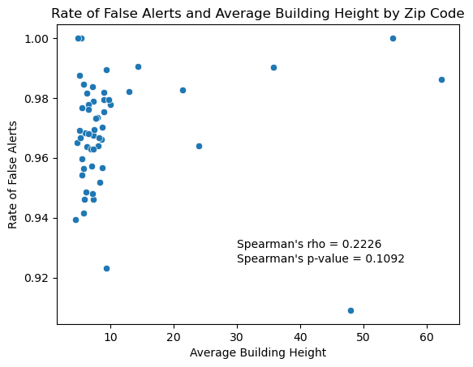

```python
#create scatterplot
fig1 = sns.scatterplot(data=faz, x=faz['Mean_BuildHeight'], y=faz['Rate_FalseAlerts'])
#add correlation coefficient and p-values to plot (Spearman)
plt.text(30,.93, 'Spearman\'s rho = ' + str(round(rs_h_corco,4)), fontsize=10)
plt.text(30,.925, 'Spearman\'s p-value = ' + str(round(rs_h_pval,4)), fontsize=10)
#add labels and title
plt.xlabel("Average Building Height")
plt.ylabel("Rate of False Alerts")
plt.title("Rate of False Alerts and Average Building Height by Zip Code")
```

```python
height_faz_scatter = fig1.get_figure()
height_faz_scatter.savefig("graphics/faz_height_scatterplot.tiff", dpi=300)
height_faz_scatter.savefig("graphics/png_faz_height_scatterplot.png")
```

### False Alerts and Average Building Density

```python
#calculate correlation coefficient (Spearman's)
rs_d = spearmanr(faz['dense_sqm'], faz['Rate_FalseAlerts'])
rs_d_corco = rs_d[0]
rs_d_pval = rs_d[1]
rs_d
```

```
SignificanceResult(statistic=np.float64(0.1416821228701337), pvalue=np.float64(0.3115464710758505))
```

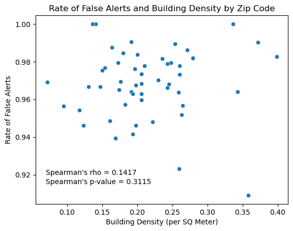

```python
#create scatterplot
fig2 = sns.scatterplot(data=faz, x=faz['dense_sqm'], y=faz['Rate_FalseAlerts'])
#add correlation coefficient and p-values to plot (Spearman)
plt.text(.07,.92, 'Spearman\'s rho = ' + str(round(rs_d_corco,4)), fontsize=10)
plt.text(.07,.915, 'Spearman\'s p-value = ' + str(round(rs_d_pval,4)), fontsize=10)
#add labels and title
plt.xlabel("Building Density (per SQ Meter)")
plt.ylabel("Rate of False Alerts")
plt.title("Rate of False Alerts and Building Density by Zip Code")
```

```python
dense_faz_scatter = fig2.get_figure()
dense_faz_scatter.savefig("graphics/faz_dense_scatterplot.tiff", dpi=300)
```

## Mapping False Alert and Building Structure Variables

### False Alerts and Average Building Height

```python
#Faz Bin List
bins = [.94, .95, .96, .97, .98, .99, 1]
bins_faz = {'bins':bins}
```

```python
# create height bins list
bins = [6, 7, 8, 9, 10, 15, 24, 48, 61.5]
bins_height = {'bins':bins}
```

```
(np.float64(337941.8664412299),
 np.float64(368745.50975123106),
 np.float64(550813.6181958015),
 np.float64(596967.8255258024))
```

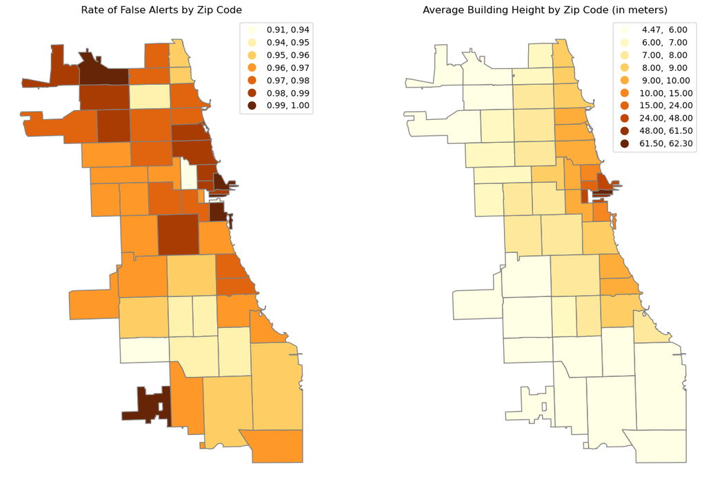

```python
fig3,axes=plt.subplots(nrows=1,ncols=2,figsize=(15,10))
#Map of False Alerts by Zip Code
faz.plot(ax=axes[0],column='Rate_FalseAlerts', scheme = 'UserDefined', classification_kwds=bins_faz, legend=True, cmap='YlOrBr', edgecolor='gray')
axes[0].set_title(f'Rate of False Alerts by Zip Code')
axes[0].axis('off')
#Average Building Height by Zip Code
faz.plot(ax=axes[1],column='Mean_BuildHeight', scheme = 'UserDefined', classification_kwds=bins_height, legend=True, cmap='YlOrBr', edgecolor='gray')
axes[1].set_title(f'Average Building Height by Zip Code (in meters)')
axes[1].axis('off')
```

```python
height_faz_map = fig3.get_figure()
height_faz_map.savefig("graphics/faz_height_map.tiff", dpi=300)
```

### False Alerts and Average Building Density

```
(np.float64(337941.8664412299),
 np.float64(368745.50975123106),
 np.float64(550813.6181958015),
 np.float64(596967.8255258024))
```

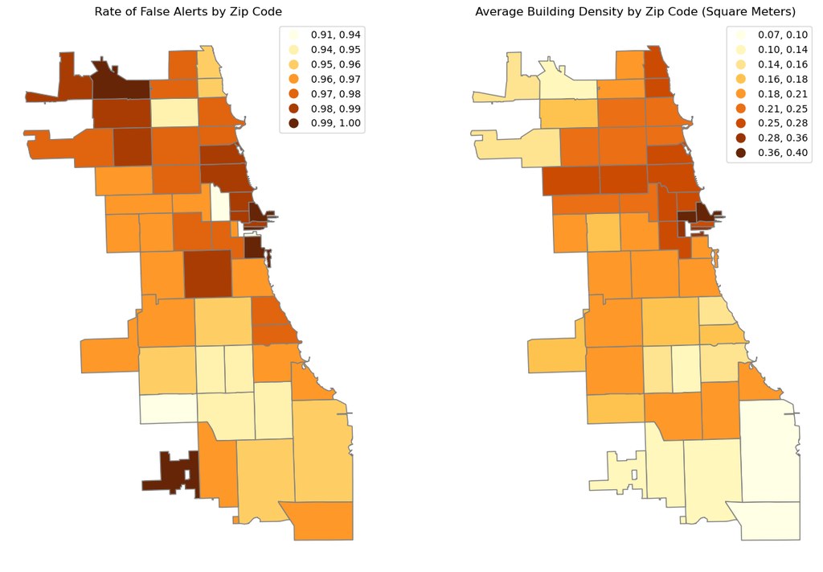

```python
fig4,axes=plt.subplots(nrows=1,ncols=2,figsize=(15,10))
#Map of False Alerts by Zip Code
faz.plot(ax=axes[0],column= 'Rate_FalseAlerts', scheme = 'UserDefined', classification_kwds=bins_faz, legend=True, cmap='YlOrBr', edgecolor='gray')
axes[0].set_title(f'Rate of False Alerts by Zip Code')
axes[0].axis('off')
#Map of Average Building Density by Zip Code
faz.plot(ax=axes[1],column= 'dense_sqm', scheme='natural_breaks', k=9, legend=True, cmap='YlOrBr', edgecolor='gray')
axes[1].set_title(f'Average Building Density by Zip Code (Square Meters)')
axes[1].axis('off')
```

```python
dense_faz_map = fig4.get_figure()
dense_faz_map.savefig("graphics/faz_dense_map.tiff", dpi=300)
```

## Mapping Residuals

### False Alerts and Average Building Height

```python
y = 'Rate_FalseAlerts'
x = 'Mean_BuildHeight'

reg = scipy.stats.linregress(x=faz[x], y=faz[y])
reg
```

```
LinregressResult(slope=np.float64(0.0001337722716848689), intercept=np.float64(0.9672116808336693), rvalue=np.float64(0.08915948873730571), pvalue=np.float64(0.5255070137820768), stderr=np.float64(0.00020925717287986048), intercept_stderr=np.float64(0.003423532186826438))
```

```python
faz['pred_height'] = reg[0]*faz[x] + reg[1]

faz['resid_height'] = faz[y] - faz['pred_height']

faz[['ZIP_CODE',x,y,'pred_height','resid_height']]
```

|  | ZIP_CODE | Mean_BuildHeight | Rate_FalseAlerts | pred_height | resid_height |
| --- | --- | --- | --- | --- | --- |
| 0 | 60601.0 | 62.295796 | 0.986081 | 0.975545 | 0.010536 |
| 1 | 60602.0 | 54.697692 | 1.000000 | 0.974529 | 0.025471 |
| 2 | 60604.0 | 47.993437 | 0.909091 | 0.973632 | -0.064541 |
| 3 | 60605.0 | 14.315238 | 0.990635 | 0.969127 | 0.021508 |
| 4 | 60607.0 | 9.981647 | 0.977894 | 0.968547 | 0.009347 |
| 5 | 60608.0 | 7.165213 | 0.983787 | 0.968170 | 0.015617 |
| 6 | 60609.0 | 7.040669 | 0.957216 | 0.968154 | -0.010937 |
| 7 | 60610.0 | 12.979562 | 0.982234 | 0.968948 | 0.013286 |
| 8 | 60611.0 | 35.779492 | 0.990345 | 0.971998 | 0.018347 |
| 9 | 60612.0 | 7.914767 | 0.973568 | 0.968270 | 0.005298 |
| 10 | 60613.0 | 9.021439 | 0.979495 | 0.968418 | 0.011077 |
| 11 | 60614.0 | 9.332707 | 0.989492 | 0.968460 | 0.021032 |
| 12 | 60615.0 | 9.789649 | 0.979350 | 0.968521 | 0.010829 |
| 13 | 60616.0 | 8.069266 | 0.963907 | 0.968291 | -0.004385 |
| 14 | 60617.0 | 5.734094 | 0.956296 | 0.967979 | -0.011683 |
| 15 | 60618.0 | 7.259130 | 0.978849 | 0.968183 | 0.010667 |
| 16 | 60619.0 | 5.919389 | 0.946075 | 0.968004 | -0.021928 |
| 17 | 60620.0 | 5.717153 | 0.941531 | 0.967976 | -0.026446 |
| 18 | 60621.0 | 7.368686 | 0.946015 | 0.968197 | -0.022182 |
| 19 | 60622.0 | 8.633266 | 0.966102 | 0.968367 | -0.002265 |
| 20 | 60623.0 | 7.300317 | 0.967558 | 0.968188 | -0.000631 |
| 21 | 60624.0 | 7.464332 | 0.969322 | 0.968210 | 0.001111 |
| 22 | 60625.0 | 7.213361 | 0.947917 | 0.968177 | -0.020260 |
| 23 | 60626.0 | 8.404413 | 0.951737 | 0.968336 | -0.016599 |
| 24 | 60628.0 | 5.474076 | 0.954266 | 0.967944 | -0.013678 |
| 25 | 60629.0 | 5.521035 | 0.959617 | 0.967950 | -0.008334 |
| 26 | 60630.0 | 5.736785 | 0.984496 | 0.967979 | 0.016517 |
| 27 | 60631.0 | 5.194456 | 0.987654 | 0.967907 | 0.019748 |
| 28 | 60632.0 | 5.971003 | 0.968203 | 0.968010 | 0.000192 |
| 29 | 60633.0 | 5.196753 | 0.969019 | 0.967907 | 0.001112 |
| 30 | 60634.0 | 5.473805 | 0.976724 | 0.967944 | 0.008780 |
| 31 | 60636.0 | 6.212614 | 0.948461 | 0.968043 | -0.019582 |
| 32 | 60637.0 | 8.189457 | 0.966721 | 0.968307 | -0.001586 |
| 33 | 60638.0 | 4.744623 | 0.964989 | 0.967846 | -0.002857 |
| 34 | 60639.0 | 6.305703 | 0.963723 | 0.968055 | -0.004332 |
| 35 | 60640.0 | 8.664894 | 0.970222 | 0.968371 | 0.001851 |
| 36 | 60641.0 | 6.332170 | 0.981651 | 0.968059 | 0.013593 |
| 37 | 60642.0 | 9.305274 | 0.923077 | 0.968456 | -0.045380 |
| 38 | 60643.0 | 5.288909 | 0.966683 | 0.967919 | -0.001236 |
| 39 | 60644.0 | 6.973023 | 0.962795 | 0.968144 | -0.005349 |
| 40 | 60645.0 | 6.510234 | 0.977764 | 0.968083 | 0.009682 |
| 41 | 60646.0 | 5.380667 | 1.000000 | 0.967931 | 0.032069 |
| 42 | 60647.0 | 7.760943 | 0.973265 | 0.968250 | 0.005015 |
| 43 | 60649.0 | 7.279151 | 0.962777 | 0.968185 | -0.005408 |
| 44 | 60651.0 | 6.500077 | 0.968166 | 0.968081 | 0.000085 |
| 45 | 60652.0 | 4.470715 | 0.939394 | 0.967810 | -0.028416 |
| 46 | 60653.0 | 9.044918 | 0.975356 | 0.968422 | 0.006935 |
| 47 | 60654.0 | 21.416500 | 0.982609 | 0.970077 | 0.012532 |
| 48 | 60655.0 | 4.867303 | 1.000000 | 0.967863 | 0.032137 |
| 49 | 60657.0 | 9.026331 | 0.981949 | 0.968419 | 0.013530 |
| 50 | 60659.0 | 6.608555 | 0.976145 | 0.968096 | 0.008049 |
| 51 | 60660.0 | 8.787943 | 0.956749 | 0.968387 | -0.011639 |
| 52 | 60661.0 | 24.032566 | 0.964126 | 0.970427 | -0.006301 |

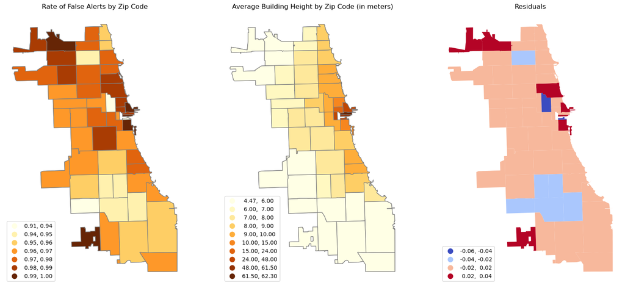

```python
# create a figure with three axes (1 by 3)
fig5,axes=plt.subplots(nrows=1,ncols=3,figsize=(20,15))
# set title for each of three axes
for i,var in enumerate([x,y,'resid_height']):
    if var == 'resid_height':
        faz.plot(ax=axes[i],column=var,scheme='StdMean',cmap='coolwarm',legend=True,legend_kwds={'loc':'lower left'})
        axes[2].set_title(f'Residuals')
        axes[2].axis('off')
    else:
        faz.plot(ax=axes[0],column='Rate_FalseAlerts', scheme = 'UserDefined', classification_kwds=bins_faz, legend=True, legend_kwds={'loc':'lower left'}, cmap='YlOrBr', edgecolor='gray')
        axes[0].set_title(f'Rate of False Alerts by Zip Code')
        axes[0].axis('off')
        #Average Building Height: User Defined
        faz.plot(ax=axes[1],column='Mean_BuildHeight', scheme = 'UserDefined', classification_kwds=bins_height, legend=True,legend_kwds={'loc':'lower left'}, cmap='YlOrBr', edgecolor='gray')
        axes[1].set_title(f'Average Building Height by Zip Code (in meters)')
        axes[1].axis('off')
```

```python
height_map_resid = fig5.get_figure()
height_map_resid.savefig("graphics/height_map_resid.tiff", dpi=300)
height_map_resid.savefig("graphics/png_height_map_resid.png")
```

### False Alerts and Average Building Density

```python
y = 'Rate_FalseAlerts'
xx = 'dense_sqm'

reg2 = scipy.stats.linregress(x=faz[xx], y=faz[y])
reg2
```

```
LinregressResult(slope=np.float64(0.01109025389173757), intercept=np.float64(0.9663215816386299), rvalue=np.float64(0.0416086335840173), pvalue=np.float64(0.7673672007449367), stderr=np.float64(0.0372903688029404), intercept_stderr=np.float64(0.008384276653965671))
```

```python
faz['pred_dense'] = reg[0]*faz[xx] + reg[1]

faz['resid_dense'] = faz[y] - faz['pred_dense']

faz[['ZIP_CODE',xx,y,'pred_dense','resid_dense']]
```

|  | ZIP_CODE | dense_sqm | Rate_FalseAlerts | pred_dense | resid_dense |
| --- | --- | --- | --- | --- | --- |
| 0 | 60601.0 | 0.271054 | 0.986081 | 0.967248 | 0.018833 |
| 1 | 60602.0 | 0.336142 | 1.000000 | 0.967257 | 0.032743 |
| 2 | 60604.0 | 0.357611 | 0.909091 | 0.967260 | -0.058169 |
| 3 | 60605.0 | 0.191354 | 0.990635 | 0.967237 | 0.023397 |
| 4 | 60607.0 | 0.259885 | 0.977894 | 0.967246 | 0.010648 |
| 5 | 60608.0 | 0.199950 | 0.983787 | 0.967238 | 0.016549 |
| 6 | 60609.0 | 0.183043 | 0.957216 | 0.967236 | -0.010020 |
| 7 | 60610.0 | 0.279316 | 0.982234 | 0.967249 | 0.014984 |
| 8 | 60611.0 | 0.372034 | 0.990345 | 0.967261 | 0.023083 |
| 9 | 60612.0 | 0.206129 | 0.973568 | 0.967239 | 0.006329 |
| 10 | 60613.0 | 0.247843 | 0.979495 | 0.967245 | 0.012250 |
| 11 | 60614.0 | 0.253786 | 0.989492 | 0.967246 | 0.022246 |
| 12 | 60615.0 | 0.172615 | 0.979350 | 0.967235 | 0.012115 |
| 13 | 60616.0 | 0.191525 | 0.963907 | 0.967237 | -0.003331 |
| 14 | 60617.0 | 0.095452 | 0.956296 | 0.967224 | -0.010928 |
| 15 | 60618.0 | 0.242729 | 0.978849 | 0.967244 | 0.011605 |
| 16 | 60619.0 | 0.197823 | 0.946075 | 0.967238 | -0.021163 |
| 17 | 60620.0 | 0.193540 | 0.941531 | 0.967238 | -0.025707 |
| 18 | 60621.0 | 0.123318 | 0.946015 | 0.967228 | -0.021213 |
| 19 | 60622.0 | 0.242853 | 0.966102 | 0.967244 | -0.001142 |
| 20 | 60623.0 | 0.198233 | 0.967558 | 0.967238 | 0.000319 |
| 21 | 60624.0 | 0.176543 | 0.969322 | 0.967235 | 0.002086 |
| 22 | 60625.0 | 0.221973 | 0.947917 | 0.967241 | -0.019325 |
| 23 | 60626.0 | 0.262773 | 0.951737 | 0.967247 | -0.015509 |
| 24 | 60628.0 | 0.117591 | 0.954266 | 0.967227 | -0.012962 |
| 25 | 60629.0 | 0.205728 | 0.959617 | 0.967239 | -0.007623 |
| 26 | 60630.0 | 0.180066 | 0.984496 | 0.967236 | 0.017260 |
| 27 | 60631.0 | 0.164190 | 0.987654 | 0.967234 | 0.020421 |
| 28 | 60632.0 | 0.205652 | 0.968203 | 0.967239 | 0.000964 |
| 29 | 60633.0 | 0.071852 | 0.969019 | 0.967221 | 0.001798 |
| 30 | 60634.0 | 0.153638 | 0.976724 | 0.967232 | 0.009492 |
| 31 | 60636.0 | 0.161048 | 0.948461 | 0.967233 | -0.018772 |
| 32 | 60637.0 | 0.147361 | 0.966721 | 0.967231 | -0.000510 |
| 33 | 60638.0 | 0.174109 | 0.964989 | 0.967235 | -0.002246 |
| 34 | 60639.0 | 0.258988 | 0.963723 | 0.967246 | -0.003524 |
| 35 | 60640.0 | 0.229921 | 0.970222 | 0.967242 | 0.002980 |
| 36 | 60641.0 | 0.235267 | 0.981651 | 0.967243 | 0.014408 |
| 37 | 60642.0 | 0.259406 | 0.923077 | 0.967246 | -0.044169 |
| 38 | 60643.0 | 0.130609 | 0.966683 | 0.967229 | -0.000546 |
| 39 | 60644.0 | 0.193952 | 0.962795 | 0.967238 | -0.004442 |
| 40 | 60645.0 | 0.210266 | 0.977764 | 0.967240 | 0.010525 |
| 41 | 60646.0 | 0.140518 | 1.000000 | 0.967230 | 0.032770 |
| 42 | 60647.0 | 0.260077 | 0.973265 | 0.967246 | 0.006018 |
| 43 | 60649.0 | 0.206138 | 0.962777 | 0.967239 | -0.004462 |
| 44 | 60651.0 | 0.245041 | 0.968166 | 0.967244 | 0.000922 |
| 45 | 60652.0 | 0.169347 | 0.939394 | 0.967234 | -0.027840 |
| 46 | 60653.0 | 0.150514 | 0.975356 | 0.967232 | 0.008124 |
| 47 | 60654.0 | 0.398292 | 0.982609 | 0.967265 | 0.015344 |
| 48 | 60655.0 | 0.136187 | 1.000000 | 0.967230 | 0.032770 |
| 49 | 60657.0 | 0.279028 | 0.981949 | 0.967249 | 0.014700 |
| 50 | 60659.0 | 0.196806 | 0.976145 | 0.967238 | 0.008907 |
| 51 | 60660.0 | 0.264690 | 0.956749 | 0.967247 | -0.010498 |
| 52 | 60661.0 | 0.342534 | 0.964126 | 0.967258 | -0.003132 |

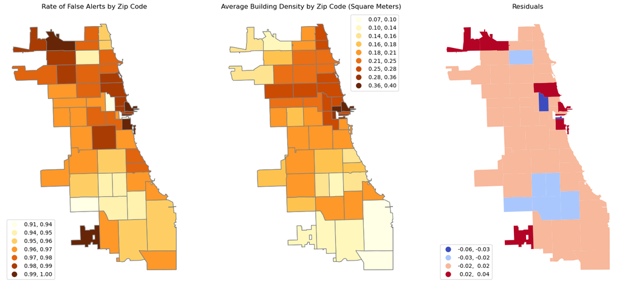

```python
# create a figure with three axes (1 by 3)
fig6,axes=plt.subplots(nrows=1,ncols=3,figsize=(20,15))
# set title for each of three axes
for i,var in enumerate([xx,y,'resid_dense']):
    if var == 'resid_dense':
        faz.plot(ax=axes[i],column=var,scheme='StdMean',cmap='coolwarm',legend=True,legend_kwds={'loc':'lower left'})
        axes[2].set_title(f'Residuals')
        axes[2].axis('off')
    else:
        faz.plot(ax=axes[0],column='Rate_FalseAlerts', scheme = 'UserDefined', classification_kwds=bins_faz, legend=True, legend_kwds={'loc':'lower left'}, cmap='YlOrBr', edgecolor='gray')
        axes[0].set_title(f'Rate of False Alerts by Zip Code')
        axes[0].axis('off')
        #Map of Average Building Density by Zip Code
        faz.plot(ax=axes[1],column= 'dense_sqm', scheme='natural_breaks', k=9, legend=True, cmap='YlOrBr', edgecolor='gray')
        axes[1].set_title(f'Average Building Density by Zip Code (Square Meters)')
        axes[1].axis('off')
```

```python
dense_map_resid = fig6.get_figure()
dense_map_resid.savefig("graphics/dense_map_resid.tiff", dpi=300)
```

[output not shown]

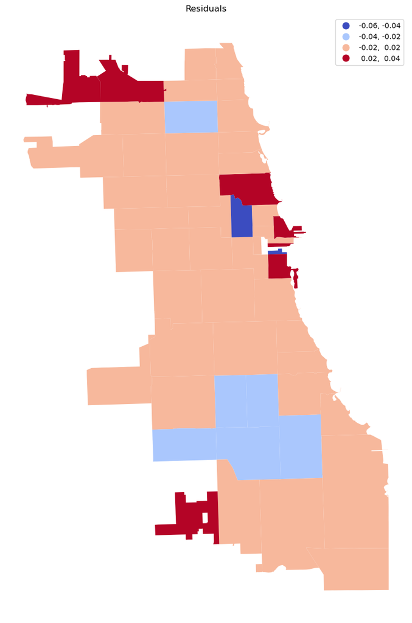

```python
fig7,axes=plt.subplots(nrows=1,ncols=1,figsize=(20,15))
faz.plot(ax=axes,column='resid_height',scheme='StdMean',cmap='coolwarm',legend=True)
axes.set_title(f'Residuals')
axes.axis('off')
```

```python
map_resid = fig7.get_figure()
map_resid.savefig("graphics/map_resid.tiff", dpi=300)
```

# Code: Explore Other Variables (Tree Canopy Coverage)

According to the residuals map, there are some zip codes where Building Height and Building Density underpredicted the Rate of False Alerts. I will investigate whether these zip codes have a high density of trees, as tree coverage is another factor that can lead to GPS errors, therefore creating false alerts in electronic monitoring. My data on tree coverage comes from the 2021 USFS Tree Canopy Cover dataset of the National Land Cover Database (NLCD). I created a layer of the data that only covered Chicago's Zip Codes.

The NLCD dataset is raster data and is not organized by zip code. Since I need to measure tree canopy coverage by zip code, I used the Zonal Statistic tool in Arc GIS to gather the tree coverage raster data by zip code. The "Zone_Stats" table contains the zonal statistics data. Each instance in this table is a Zip Code.

Below is a multiple regression analysis with the Rate of False Alerts as the dependent variable and "Tree Density" and "Average Building Height" as the independent variable. I am defining "Tree Density" as the "SUM" field divided by the "COUNT" field.

### Load Zonal Statistics Table

```python
zone_stats = pd.read_excel('data/ZonalSt_Chi_Zip1_TableToExcel.xlsx')
```

```python
zone_stats
```

|  | OBJECTID | ZIP_CODE | ZONE_CODE | COUNT | AREA | MIN | MAX | RANGE | MEAN | STD | SUM | VARIETY | MAJORITY | MAJORITY_COUNT | MAJORITY_PERCENT | MINORITY | MINORITY_COUNT | MINORITY_PERCENT | MEDIAN | PCT90 |
| --- | --- | --- | --- | --- | --- | --- | --- | --- | --- | --- | --- | --- | --- | --- | --- | --- | --- | --- | --- | --- |
| 0 | 1 | 60660 | 1 | 3578 | 3220200 | 0 | 44 | 44 | 4.555618 | 7.069752 | 16300 | 36 | 0 | 2381 | 66.545601 | 28 | 1 | 0.0279 | 0 | 15 |
| 1 | 2 | 60607 | 2 | 6594 | 5934600 | 0 | 59 | 59 | 1.455869 | 4.677654 | 9600 | 43 | 0 | 5871 | 89.035500 | 4 | 1 | 0.0152 | 0 | 9 |
| 2 | 3 | 60714 | 3 | 1004 | 903600 | 0 | 91 | 91 | 49.796813 | 27.664692 | 49996 | 87 | 0 | 106 | 10.557800 | 6 | 2 | 0.1992 | 58 | 81 |
| 3 | 4 | 60624 | 4 | 10221 | 9198900 | 0 | 75 | 75 | 3.744448 | 6.921962 | 38272 | 57 | 0 | 7381 | 72.214104 | 2 | 1 | 0.0098 | 0 | 13 |
| 4 | 5 | 60456 | 5 | 7 | 6300 | 0 | 0 | 0 | 0.000000 | 0.000000 | 0 | 1 | 0 | 7 | 100.000000 | 0 | 7 | 100.0000 | 0 | 0 |
| ... | ... | ... | ... | ... | ... | ... | ... | ... | ... | ... | ... | ... | ... | ... | ... | ... | ... | ... | ... | ... |
| 77 | 78 | 60712 | 78 | 75 | 67500 | 0 | 27 | 27 | 5.920000 | 9.057976 | 444 | 16 | 0 | 50 | 66.666702 | 5 | 1 | 1.3333 | 0 | 21 |
| 78 | 79 | 60612 | 79 | 10973 | 9875700 | 0 | 51 | 51 | 1.731432 | 4.318935 | 18999 | 37 | 0 | 9283 | 84.598602 | 6 | 1 | 0.0091 | 0 | 10 |
| 79 | 80 | 60645 | 80 | 6360 | 5724000 | 0 | 81 | 81 | 7.922799 | 8.649364 | 50389 | 52 | 0 | 2964 | 46.603802 | 43 | 1 | 0.0157 | 9 | 18 |
| 80 | 81 | 60623 | 81 | 15652 | 14086800 | 0 | 254 | 254 | 3.849987 | 7.554072 | 60260 | 69 | 0 | 11113 | 71.000504 | 42 | 1 | 0.0064 | 0 | 13 |
| 81 | 82 | 60653 | 82 | 6998 | 6298200 | 0 | 87 | 87 | 4.011861 | 8.031607 | 28075 | 68 | 0 | 4903 | 70.062897 | 4 | 1 | 0.0143 | 0 | 12 |

82 rows × 20 columns

### Create Tree Density Field

```python
tree_dense = zone_stats[['OBJECTID','ZIP_CODE', 'COUNT','SUM']]
tree_dense['tree_dense'] = tree_dense['SUM']/tree_dense['COUNT']
tree_dense
```

|  | OBJECTID | ZIP_CODE | COUNT | SUM | tree_dense |
| --- | --- | --- | --- | --- | --- |
| 0 | 1 | 60660 | 3578 | 16300 | 4.555618 |
| 1 | 2 | 60607 | 6594 | 9600 | 1.455869 |
| 2 | 3 | 60714 | 1004 | 49996 | 49.796813 |
| 3 | 4 | 60624 | 10221 | 38272 | 3.744448 |
| 4 | 5 | 60456 | 7 | 0 | 0.000000 |
| ... | ... | ... | ... | ... | ... |
| 77 | 78 | 60712 | 75 | 444 | 5.920000 |
| 78 | 79 | 60612 | 10973 | 18999 | 1.731432 |
| 79 | 80 | 60645 | 6360 | 50389 | 7.922799 |
| 80 | 81 | 60623 | 15652 | 60260 | 3.849987 |
| 81 | 82 | 60653 | 6998 | 28075 | 4.011861 |

82 rows × 5 columns

```python
faz_zone = faz.copy()
faz_zone = faz_zone.drop(columns=['pred_height','resid_height','pred_dense','resid_dense'])
faz_zone.head()
```

|  | OBJECTID | ZIP_CODE | Total_Alerts | False_Alerts | shape_area | shape_len | geometry | area_sqm | Sum_BuildSize | dense_sqm | Mean_BuildHeight | Rate_FalseAlerts |
| --- | --- | --- | --- | --- | --- | --- | --- | --- | --- | --- | --- | --- |
| 0 | 1 | 60601.0 | 934.0 | 921.0 | 9166245.7499 | 19804.5819922 | MULTIPOLYGON (((358976.431 579999.88, 359009.3... | 8.515755e+05 | 2.308227e+05 | 0.271054 | 62.295796 | 0.986081 |
| 1 | 2 | 60602.0 | 4.0 | 4.0 | 4847124.84463 | 14448.1742715 | MULTIPOLYGON (((359519.985 579268.097, 359515.... | 4.503144e+05 | 1.513696e+05 | 0.336142 | 54.697692 | 1.000000 |
| 2 | 3 | 60604.0 | 33.0 | 30.0 | 4294901.86284 | 12245.807943 | MULTIPOLYGON (((358068.454 578926.793, 358068.... | 3.990110e+05 | 1.426908e+05 | 0.357611 | 47.993437 | 0.909091 |
| 3 | 4 | 60605.0 | 1922.0 | 1904.0 | 36301276.0113 | 37973.3467309 | MULTIPOLYGON (((359159.101 578692.478, 359428.... | 3.372512e+06 | 6.453445e+05 | 0.191354 | 14.315238 | 0.990635 |
| 4 | 5 | 60607.0 | 1719.0 | 1681.0 | 64664294.2344 | 39143.6400726 | MULTIPOLYGON (((356932.304 579351.246, 356932.... | 6.007534e+06 | 1.561269e+06 | 0.259885 | 9.981647 | 0.977894 |

```python
faz_zone.columns
```

```
Index(['OBJECTID', 'ZIP_CODE', 'Total_Alerts', 'False_Alerts', 'shape_area',
       'shape_len', 'geometry', 'area_sqm', 'Sum_BuildSize', 'dense_sqm',
       'Mean_BuildHeight', 'Rate_FalseAlerts'],
      dtype='object')
```

```python
#cbs_full = pd.merge(cbs, null_zcodes_clean, on = "BUILD_ID", how = "left")
faz_tree = pd.merge(faz_zone, tree_dense, on = 'ZIP_CODE', how = 'left')
faz_tree_mapping = faz_tree.copy()
faz_tree = faz_tree.drop(columns=['shape_area','shape_len', 'geometry'])
faz_tree
```

|  | OBJECTID_x | ZIP_CODE | Total_Alerts | False_Alerts | area_sqm | Sum_BuildSize | dense_sqm | Mean_BuildHeight | Rate_FalseAlerts | OBJECTID_y | COUNT | SUM | tree_dense |
| --- | --- | --- | --- | --- | --- | --- | --- | --- | --- | --- | --- | --- | --- |
| 0 | 1 | 60601.0 | 934.0 | 921.0 | 8.515755e+05 | 2.308227e+05 | 0.271054 | 62.295796 | 0.986081 | 9 | 958 | 1697 | 1.771399 |
| 1 | 2 | 60602.0 | 4.0 | 4.0 | 4.503144e+05 | 1.513696e+05 | 0.336142 | 54.697692 | 1.000000 | 60 | 333 | 783 | 2.351351 |
| 2 | 3 | 60604.0 | 33.0 | 30.0 | 3.990110e+05 | 1.426908e+05 | 0.357611 | 47.993437 | 0.909091 | 13 | 247 | 10 | 0.040486 |
| 3 | 4 | 60605.0 | 1922.0 | 1904.0 | 3.372512e+06 | 6.453445e+05 | 0.191354 | 14.315238 | 0.990635 | 46 | 4267 | 15370 | 3.602062 |
| 4 | 5 | 60607.0 | 1719.0 | 1681.0 | 6.007534e+06 | 1.561269e+06 | 0.259885 | 9.981647 | 0.977894 | 2 | 6594 | 9600 | 1.455869 |
| 5 | 6 | 60608.0 | 24919.0 | 24515.0 | 1.639796e+07 | 3.278769e+06 | 0.199950 | 7.165213 | 0.983787 | 53 | 18267 | 36149 | 1.978924 |
| 6 | 7 | 60609.0 | 1940.0 | 1857.0 | 1.983398e+07 | 3.630475e+06 | 0.183043 | 7.040669 | 0.957216 | 63 | 21850 | 85843 | 3.928741 |
| 7 | 8 | 60610.0 | 2364.0 | 2322.0 | 2.935577e+06 | 8.199528e+05 | 0.279316 | 12.979562 | 0.982234 | 36 | 3070 | 7100 | 2.312704 |
| 8 | 9 | 60611.0 | 725.0 | 718.0 | 2.183793e+06 | 8.124456e+05 | 0.372034 | 35.779492 | 0.990345 | 50 | 2376 | 3583 | 1.507997 |
| 9 | 10 | 60612.0 | 4313.0 | 4199.0 | 9.914554e+06 | 2.043678e+06 | 0.206129 | 7.914767 | 0.973568 | 79 | 10973 | 18999 | 1.731432 |
| 10 | 11 | 60613.0 | 634.0 | 621.0 | 5.015938e+06 | 1.243163e+06 | 0.247843 | 9.021439 | 0.979495 | 26 | 5402 | 36031 | 6.669937 |
| 11 | 12 | 60614.0 | 571.0 | 565.0 | 8.775715e+06 | 2.227156e+06 | 0.253786 | 9.332707 | 0.989492 | 56 | 9629 | 41991 | 4.360889 |
| 12 | 13 | 60615.0 | 6247.0 | 6118.0 | 6.184158e+06 | 1.067476e+06 | 0.172615 | 9.789649 | 0.979350 | 6 | 6797 | 40313 | 5.930999 |
| 13 | 14 | 60616.0 | 1413.0 | 1362.0 | 1.018844e+07 | 1.951337e+06 | 0.191525 | 8.069266 | 0.963907 | 39 | 10878 | 29585 | 2.719710 |
| 14 | 15 | 60617.0 | 3661.0 | 3501.0 | 4.207014e+07 | 4.015693e+06 | 0.095452 | 5.734094 | 0.956296 | 49 | 50782 | 437452 | 8.614312 |
| 15 | 16 | 60618.0 | 1182.0 | 1157.0 | 1.312129e+07 | 3.184915e+06 | 0.242729 | 7.259130 | 0.978849 | 15 | 14560 | 64950 | 4.460852 |
| 16 | 17 | 60619.0 | 7733.0 | 7316.0 | 1.559588e+07 | 3.085217e+06 | 0.197823 | 5.919389 | 0.946075 | 40 | 17557 | 134911 | 7.684172 |
| 17 | 18 | 60620.0 | 4481.0 | 4219.0 | 1.766462e+07 | 3.418803e+06 | 0.193540 | 5.717153 | 0.941531 | 67 | 19884 | 150102 | 7.548884 |
| 18 | 19 | 60621.0 | 4279.0 | 4048.0 | 9.731337e+06 | 1.200051e+06 | 0.123318 | 7.368686 | 0.946015 | 18 | 10849 | 80062 | 7.379666 |
| 19 | 20 | 60622.0 | 708.0 | 684.0 | 6.582563e+06 | 1.598597e+06 | 0.242853 | 8.633266 | 0.966102 | 28 | 7466 | 20897 | 2.798955 |
| 20 | 21 | 60623.0 | 5949.0 | 5756.0 | 1.442656e+07 | 2.859817e+06 | 0.198233 | 7.300317 | 0.967558 | 81 | 15652 | 60260 | 3.849987 |
| 21 | 22 | 60624.0 | 5085.0 | 4929.0 | 9.236283e+06 | 1.630604e+06 | 0.176543 | 7.464332 | 0.969322 | 4 | 10221 | 38272 | 3.744448 |
| 22 | 23 | 60625.0 | 768.0 | 728.0 | 9.832053e+06 | 2.182455e+06 | 0.221973 | 7.213361 | 0.947917 | 57 | 10540 | 70233 | 6.663472 |
| 23 | 24 | 60626.0 | 1036.0 | 986.0 | 4.568115e+06 | 1.200378e+06 | 0.262773 | 8.404413 | 0.951737 | 65 | 5066 | 27279 | 5.384722 |
| 24 | 25 | 60628.0 | 4876.0 | 4653.0 | 3.207413e+07 | 3.771636e+06 | 0.117591 | 5.474076 | 0.954266 | 12 | 31351 | 292470 | 9.328889 |
| 25 | 26 | 60629.0 | 3442.0 | 3303.0 | 1.961328e+07 | 4.034996e+06 | 0.205728 | 5.521035 | 0.959617 | 48 | 21729 | 119485 | 5.498872 |
| 26 | 27 | 60630.0 | 258.0 | 254.0 | 1.217720e+07 | 2.192694e+06 | 0.180066 | 5.736785 | 0.984496 | 74 | 13626 | 142963 | 10.491927 |
| 27 | 28 | 60631.0 | 405.0 | 400.0 | 9.951590e+06 | 1.633954e+06 | 0.164190 | 5.194456 | 0.987654 | 24 | 10802 | 115681 | 10.709221 |
| 28 | 29 | 60632.0 | 2170.0 | 2101.0 | 1.967279e+07 | 4.045754e+06 | 0.205652 | 5.971003 | 0.968203 | 54 | 22131 | 72829 | 3.290814 |
| 29 | 30 | 60633.0 | 581.0 | 563.0 | 1.742187e+07 | 1.251787e+06 | 0.071852 | 5.196753 | 0.969019 | 62 | 19207 | 172141 | 8.962410 |
| 30 | 31 | 60634.0 | 1160.0 | 1133.0 | 1.802908e+07 | 2.769947e+06 | 0.153638 | 5.473805 | 0.976724 | 35 | 18889 | 230952 | 12.226799 |
| 31 | 32 | 60636.0 | 2697.0 | 2558.0 | 9.672611e+06 | 1.557753e+06 | 0.161048 | 6.212614 | 0.948461 | 45 | 10889 | 89265 | 8.197722 |
| 32 | 33 | 60637.0 | 6100.0 | 5897.0 | 1.165234e+07 | 1.717101e+06 | 0.147361 | 8.189457 | 0.966721 | 20 | 13008 | 86050 | 6.615160 |
| 33 | 34 | 60638.0 | 457.0 | 441.0 | 1.543742e+07 | 2.687788e+06 | 0.174109 | 4.744623 | 0.964989 | 31 | 17373 | 73610 | 4.237034 |
| 34 | 35 | 60639.0 | 3997.0 | 3852.0 | 1.184296e+07 | 3.067179e+06 | 0.258988 | 6.305703 | 0.963723 | 61 | 13181 | 51667 | 3.919809 |
| 35 | 36 | 60640.0 | 1847.0 | 1792.0 | 7.181921e+06 | 1.651276e+06 | 0.229921 | 8.664894 | 0.970222 | 10 | 8249 | 38384 | 4.653170 |
| 36 | 37 | 60641.0 | 1744.0 | 1712.0 | 1.058201e+07 | 2.489599e+06 | 0.235267 | 6.332170 | 0.981651 | 41 | 11776 | 65294 | 5.544667 |
| 37 | 38 | 60642.0 | 143.0 | 132.0 | 4.455786e+06 | 1.155860e+06 | 0.259406 | 9.305274 | 0.923077 | 73 | 4919 | 4652 | 0.945721 |
| 38 | 39 | 60643.0 | 2071.0 | 2002.0 | 1.929662e+07 | 2.520304e+06 | 0.130609 | 5.288909 | 0.966683 | 22 | 21018 | 274588 | 13.064421 |
| 39 | 40 | 60644.0 | 4193.0 | 4037.0 | 9.206005e+06 | 1.785525e+06 | 0.193952 | 6.973023 | 0.962795 | 32 | 10262 | 48831 | 4.758429 |
| 40 | 41 | 60645.0 | 1664.0 | 1627.0 | 5.776871e+06 | 1.214681e+06 | 0.210266 | 6.510234 | 0.977764 | 80 | 6360 | 50389 | 7.922799 |
| 41 | 42 | 60646.0 | 77.0 | 77.0 | 1.095239e+07 | 1.539007e+06 | 0.140518 | 5.380667 | 1.000000 | 7 | 11023 | 202269 | 18.349723 |
| 42 | 43 | 60647.0 | 1945.0 | 1893.0 | 9.852619e+06 | 2.562442e+06 | 0.260077 | 7.760943 | 0.973265 | 58 | 10977 | 36355 | 3.311925 |
| 43 | 44 | 60649.0 | 5588.0 | 5380.0 | 7.481147e+06 | 1.542147e+06 | 0.206138 | 7.279151 | 0.962777 | 68 | 8337 | 50681 | 6.079045 |
| 44 | 45 | 60651.0 | 3801.0 | 3680.0 | 9.201119e+06 | 2.254648e+06 | 0.245041 | 6.500077 | 0.968166 | 21 | 10184 | 39340 | 3.862922 |
| 45 | 46 | 60652.0 | 561.0 | 527.0 | 1.192042e+07 | 2.018688e+06 | 0.169347 | 4.470715 | 0.939394 | 52 | 13069 | 68838 | 5.267274 |
| 46 | 47 | 60653.0 | 2597.0 | 2533.0 | 6.295119e+06 | 9.475017e+05 | 0.150514 | 9.044918 | 0.975356 | 82 | 6998 | 28075 | 4.011861 |
| 47 | 48 | 60654.0 | 115.0 | 113.0 | 1.474374e+06 | 5.872314e+05 | 0.398292 | 21.416500 | 0.982609 | 30 | 1801 | 610 | 0.338701 |
| 48 | 49 | 60655.0 | 6.0 | 6.0 | 1.071921e+07 | 1.459813e+06 | 0.136187 | 4.867303 | 1.000000 | 47 | 10692 | 99067 | 9.265526 |
| 49 | 50 | 60657.0 | 277.0 | 272.0 | 5.903803e+06 | 1.647325e+06 | 0.279028 | 9.026331 | 0.981949 | 25 | 6395 | 20152 | 3.151212 |
| 50 | 51 | 60659.0 | 1048.0 | 1023.0 | 6.475220e+06 | 1.274363e+06 | 0.196806 | 6.608555 | 0.976145 | 55 | 7942 | 83052 | 10.457316 |
| 51 | 52 | 60660.0 | 1341.0 | 1283.0 | 3.528879e+06 | 9.340599e+05 | 0.264690 | 8.787943 | 0.956749 | 1 | 3578 | 16300 | 4.555618 |
| 52 | 53 | 60661.0 | 223.0 | 215.0 | 8.693674e+05 | 2.977878e+05 | 0.342534 | 24.032566 | 0.964126 | 33 | 956 | 350 | 0.366109 |

### Start Multiple Regression Analysis : Exploring Data

```python
import pandas as pd
from sklearn.model_selection import train_test_split
from sklearn.linear_model import LinearRegression
from sklearn.metrics import mean_squared_error, r2_score
import matplotlib.pyplot as plt
import seaborn as sns
```

```python
data = faz_tree
data.columns
```

```
Index(['OBJECTID_x', 'ZIP_CODE', 'Total_Alerts', 'False_Alerts', 'area_sqm',
       'Sum_BuildSize', 'dense_sqm', 'Mean_BuildHeight', 'Rate_FalseAlerts',
       'OBJECTID_y', 'COUNT', 'SUM', 'tree_dense'],
      dtype='object')
```

```python
# Select features (independent variables) and target (dependent variable)
x = data[['Mean_BuildHeight', 'tree_dense']]
y = data['Rate_FalseAlerts']
```

```python
# Split data into training and testing sets
X_train, X_test, y_train, y_test = train_test_split(x, y, test_size=0.2, random_state=42)
```

```python
# Create a linear regression model
model = LinearRegression()
```

```python
# Train the model
model.fit(X_train, y_train)
```

```
LinearRegression()
```

```python
# Make predictions on the test set
y_pred = model.predict(X_test)
```

```python
# Evaluate the model
mse = mean_squared_error(y_test, y_pred)
r2 = r2_score(y_test, y_pred)
print(f'Mean Squared Error: {mse}')
print(f'R-squared: {r2}')
```

```
Mean Squared Error: 0.00024293013221539034
R-squared: -0.046597785463304175
```

```python
# Get coefficients and intercept
print(f'Coefficients: {model.coef_}')
print(f'Intercept: {model.intercept_}')
```

```
Coefficients: [0.00026356 0.00118241]
Intercept: 0.9580310059159727
```

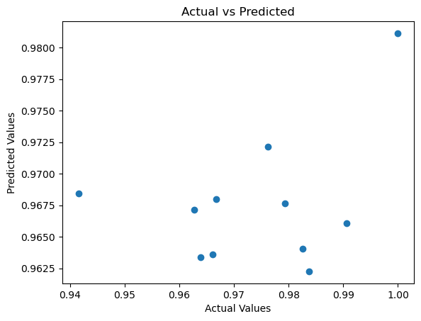

```python
# Visualize predicted vs actual
fig8 = plt.scatter(y_test, y_pred)
plt.xlabel('Actual Values')
plt.ylabel('Predicted Values')
plt.title('Actual vs Predicted')
plt.show()
```

```python
pred_v_act = fig8.get_figure()
pred_v_act.savefig("graphics/pred_v_act.png")
```

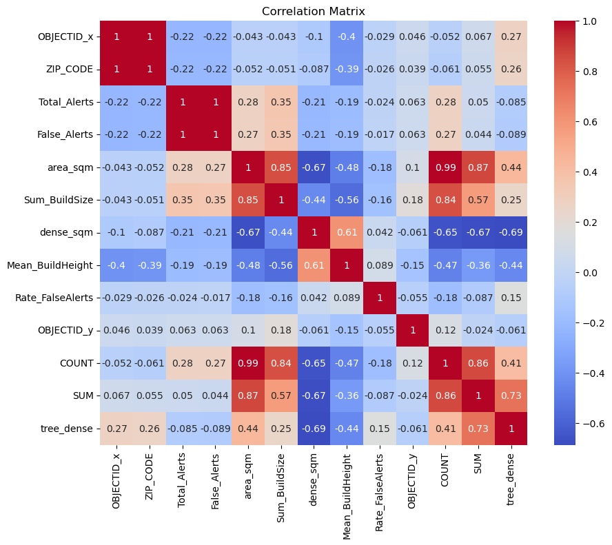

```python
# Correlation matrix visualization
corr_matrix = data.corr()
fig9 = plt.figure(figsize=(10, 8))
sns.heatmap(corr_matrix, annot=True, cmap='coolwarm')
plt.title('Correlation Matrix')
plt.show()
```

```python
tree_corr_matrix = fig9.get_figure()
tree_corr_matrix.savefig("graphics/tree_corr_matrix.png")
```

#### Additional Sample Code

```python
import statsmodels.api as sm
```

```python
data.columns
```

```
Index(['OBJECTID_x', 'ZIP_CODE', 'Total_Alerts', 'False_Alerts', 'area_sqm',
       'Sum_BuildSize', 'dense_sqm', 'Mean_BuildHeight', 'Rate_FalseAlerts',
       'OBJECTID_y', 'COUNT', 'SUM', 'tree_dense'],
      dtype='object')
```

```python
# Define the dependent variable and independent variables
y = data['Rate_FalseAlerts']
X = data[['Mean_BuildHeight', 'tree_dense']]
```

```python
# Add a constant term to the independent variables (for the intercept)
X = sm.add_constant(X)
```

```python
# Fit the multiple linear regression model
model = sm.OLS(y, X)
results = model.fit()
```

```python
#Print the regression results, including t-statistics and p-values
print(results.summary())
```

```
                            OLS Regression Results
==============================================================================
Dep. Variable:       Rate_FalseAlerts   R-squared:                       0.054
Model:                            OLS   Adj. R-squared:                  0.016
Method:                 Least Squares   F-statistic:                     1.428
Date:                Thu, 26 Feb 2026   Prob (F-statistic):              0.249
Time:                        13:58:59   Log-Likelihood:                 139.20
No. Observations:                  53   AIC:                            -272.4
Df Residuals:                      50   BIC:                            -266.5
Df Model:                           2
Covariance Type:            nonrobust
====================================================================================
                       coef    std err          t      P>|t|      [0.025      0.975]
------------------------------------------------------------------------------------
const                0.9589      0.006    151.946      0.000       0.946       0.972
Mean_BuildHeight     0.0003      0.000      1.273      0.209      -0.000       0.001
tree_dense           0.0012      0.001      1.561      0.125      -0.000       0.003
==============================================================================
Omnibus:                       15.379   Durbin-Watson:                   1.849
Prob(Omnibus):                  0.000   Jarque-Bera (JB):               18.374
Skew:                          -1.120   Prob(JB):                     0.000102
Kurtosis:                       4.817   Cond. No.                         42.6
==============================================================================

Notes:
[1] Standard Errors assume that the covariance matrix of the errors is correctly specified.
```

### Map Tree Density By Zip Code

```python
#Faz Bin List
bins = [.94, .95, .96, .97, .98, .99, 1]
bins_faz = {'bins':bins}
```

[output not shown]

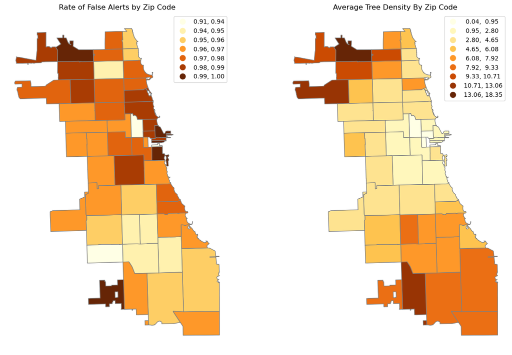

```python
fig10,axes=plt.subplots(nrows=1,ncols=2,figsize=(15,10))
#Map of False Alerts by Zip Code
faz_tree_mapping.plot(ax=axes[0],column='Rate_FalseAlerts', scheme='UserDefined', classification_kwds=bins_faz, legend=True, cmap='YlOrBr', edgecolor='gray')
axes[0].set_title(f'Rate of False Alerts by Zip Code')
axes[0].axis('off')
#Tree Desnity by Zip Code
faz_tree_mapping.plot(ax=axes[1],column='tree_dense', scheme='natural_breaks', k=9, legend=True, cmap='YlOrBr', edgecolor='gray')
axes[1].set_title(f'Average Tree Density By Zip Code')
axes[1].axis('off')
```

```python
tree_dense_map = fig10.get_figure()
tree_dense_map.savefig("graphics/tree_dense_map.png")
```

[output not shown]

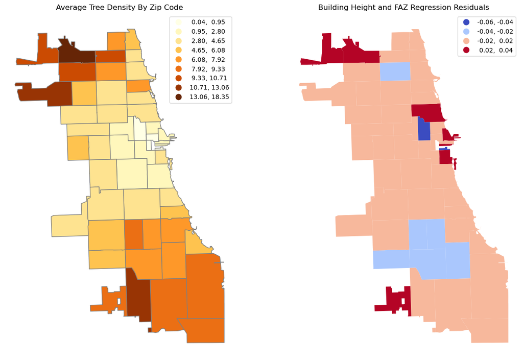

```python
fig11,axes=plt.subplots(nrows=1,ncols=2,figsize=(15,10))
#Tree Desnity by Zip Code
faz_tree_mapping.plot(ax=axes[0],column='tree_dense', scheme='natural_breaks', k=9, legend=True, cmap='YlOrBr', edgecolor='gray')
axes[0].set_title(f'Average Tree Density By Zip Code')
axes[0].axis('off')
#residuals from Building Height and FAZ Regression
faz.plot(ax=axes[1],column='resid_height',scheme='StdMean',cmap='coolwarm',legend=True)
axes[1].set_title(f'Building Height and FAZ Regression Residuals')
axes[1].axis('off')
```

```python
tree_dense_Faz_resid_map = fig11.get_figure()
tree_dense_Faz_resid_map.savefig("graphics/tree_dense_Faz_resid_map.png")
```

[output not shown]

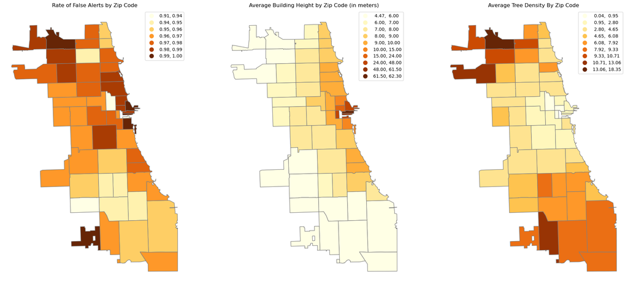

```python
fig12,axes=plt.subplots(nrows=1,ncols=3,figsize=(25,15))
#Map of False Alerts by Zip Code
faz.plot(ax=axes[0],column='Rate_FalseAlerts', scheme = 'UserDefined', classification_kwds=bins_faz, legend=True, cmap='YlOrBr', edgecolor='gray')
axes[0].set_title(f'Rate of False Alerts by Zip Code')
axes[0].axis('off')
#Average Building Height by Zip Code
faz.plot(ax=axes[1],column='Mean_BuildHeight', scheme = 'UserDefined', classification_kwds=bins_height, legend=True, cmap='YlOrBr', edgecolor='gray')
axes[1].set_title(f'Average Building Height by Zip Code (in meters)')
axes[1].axis('off')
#Tree Desnity by Zip Code
faz_tree_mapping.plot(ax=axes[2],column='tree_dense', scheme='natural_breaks', k=9, legend=True, cmap='YlOrBr', edgecolor='gray')
axes[2].set_title(f'Average Tree Density By Zip Code')
axes[2].axis('off')
```

```python
q2_map = fig12.get_figure()
q2_map.savefig("graphics/q2_map.tiff", dpi=300)
```

# Presenting Results

## Rate of False Alerts and Building Height

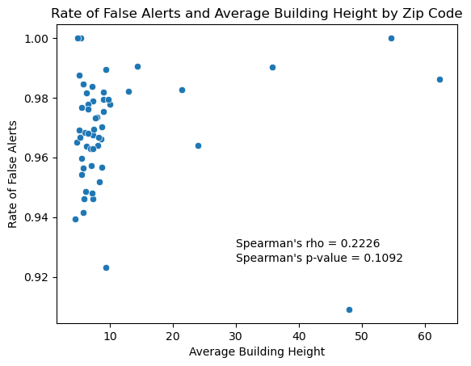

```python
height_faz_scatter
```

The evidence suggests a weak association between the rate of false alerts and building height.

The average height of these zip codes ranges from 12.97 meters (4 stories) to 62.3 meters (20 stories). Three zip codes have a 100% false alert rate, and their average building heights are 54.7 meters, 5.38 meters, and 4.87 meters. One zip code has the lowest false alert rate (60604), 90.91%, and its average building height is 47.99 meters.

The results of Spearman's correlation analysis between building height and the rate of false alerts yield a coefficient value of 0.2226 with a p-value of 0.1092. This indicates a weak positive curvilinear relationship between building height and a zip code's rate of false alerts. The correlation analysis provided a p-value of .1092. This p-value is not statistically significant, and based on this value, we cannot reject the null hypothesis that there is no association between building height and the rate of false alerts.

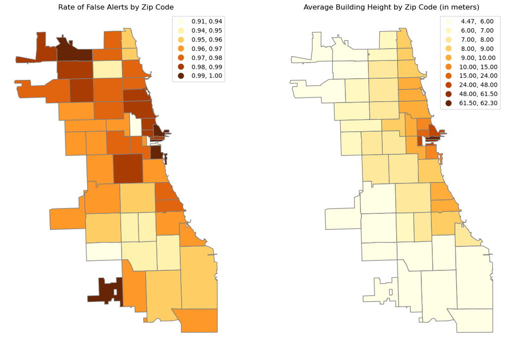

```python
fig3
```

Figure #3 shows the relationship between the rate of false alerts by zip and the average building height in Chicago. There is a slight spatial pattern: rates of false alerts are high along the shore of Lake Michigan. These areas have a higher average building height, as there are many high-rise buildings along the lakefront. The zip codes with the highest average building height are in the downtown business district (the “Loop”), and zip codes farthest from the Loop have the lowest building height.

## Rate of False Alerts and Building Density

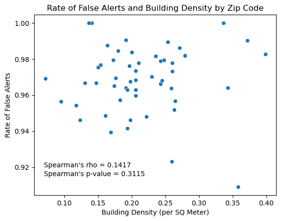

```python
dense_faz_scatter
```

The evidence suggests a weak association between the rate of false alerts and building density.

The zip code with the highest building density (60654) had a false alert rate of 98.26%, the 11th highest false alert rate in the data set.. The zip code with the lowest building density (60633) had a false alert rate of 96.9%.

The analysis provides Spearman’s rho of .1417, indicating a very weak positive curvlinear relationship between building density and the rate of false alerts in a zip code. The correlation analysis also provided a p-value of .3115. This p-value is not statistically significant, suggesting we cannot reject the null hypothesis that there is no association between building density and the rate of false alerts.

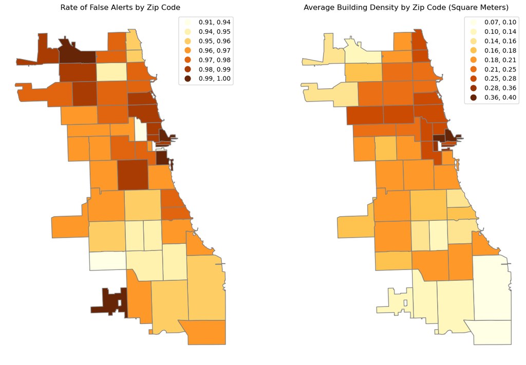

```python
fig4
```

There is a slight spatial pattern: the denser zip codes north of the loop also have a higher rate of false alerts, but high false alert rates are not exclusive to those areas.

## Mapping Residuals

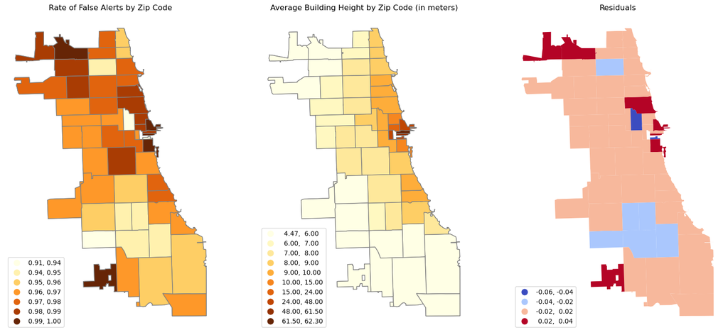

```python
fig5
```

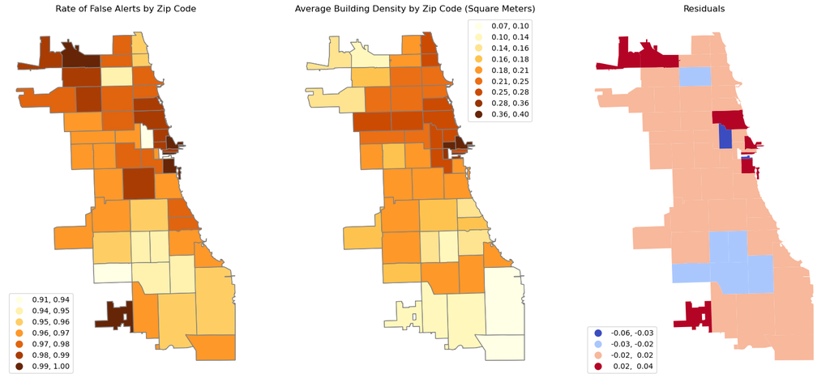

```python
fig6
```

In the regression residual maps, red zip codes are where building height/density underpredicted the rate of false alerts, and the blue zip codes are where building height/density overpredicted the rate of false alerts.

The zip codes in dark red are my main areas of interest: there are some zip codes near the loop, but three zip codes are on opposite sides of the city.

My preliminary research indicates these zip codes have a higher tree canopy than the rest of the city, which is why I am exploring tree coverage data as an explanatory variable.

## Tree Canopy Coverage and Building Height Residuals

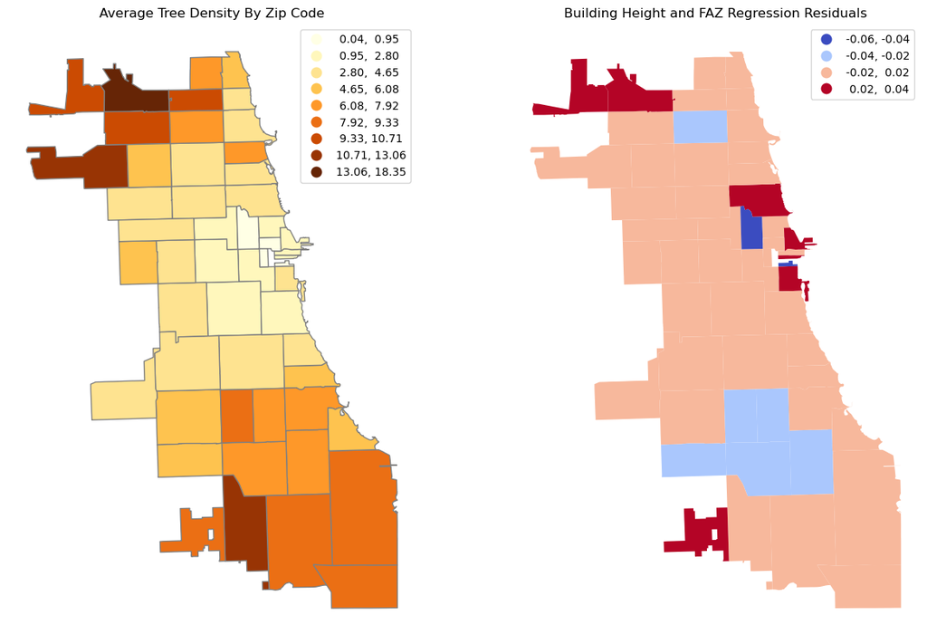

```python
fig11
```

Fig #11 shows the tree canopy density per zip code in Chicago.

There is a relationship between tree canopy density and the dark red zip codes, where building height/density underpredicted the rate of false alerts. The zip codes at the top left and bottom left of the maps have a higher tree canopy density, and building height and density also underpredicted the rate of false alerts in these areas. However, the dark red zip codes in and near the loop do not have dense tree canopy: it is unlikely that tree coverage is an explanatory variable for the rate of false alerts in these areas.

Further research is needed: Perhaps highway infrastructure is blocking GPS signals in these zip codes? Highway overpasses are not captured in the FEMA structure data. Also, Chicago's Lower Wacker Drive may run through these zip codes. That underground highway is notorious for not having GPS access.

# Conclusion

Based on the data I received from the Sheriff's Office, the Cook County Electronic Monitoring program has an extraordinarily high rate of false alerts: the minimum rate for false alerts in a zip code was 90.9 percent. Even 60608, the zip code with the highest number of total alerts (n = 24,919), had a false alert rate of 98.37 percent. While there is something amiss with the Electronic Monitoring program, my research suggests that building height and density are unlikely to be the cause of the high rates of false alerts.

My analysis indicates a weak, positive relationship between the rate of false alerts and zip codes with a high average building height and high building density. However, the evidence is not strong enough to reject the null hypothesis that there is no relationship between these variables. Further research is needed to understand the relationship between tree canopy coverage and the rate of false alerts.

Further research is needed to understand why Cook County's Electronic Monitoring system has such a high rate of false alerts. There are real, human consequences for false alerts: people in the justice system have reported harassment from law enforcement officials because of these false alerts. People under electronic monitoring can follow all of the rules and still be treated as a flight risk. Our justice system is committing harm by allowing such a high rate of these false alerts.